# R Markdown

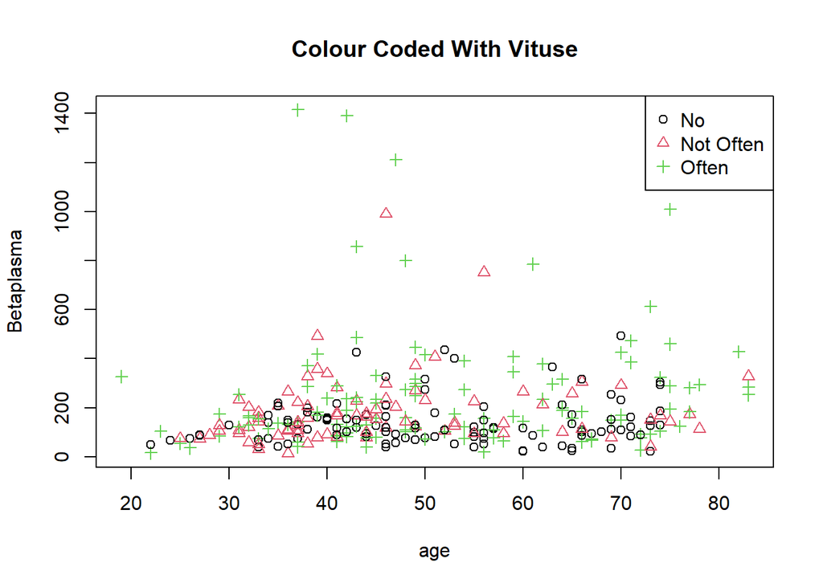

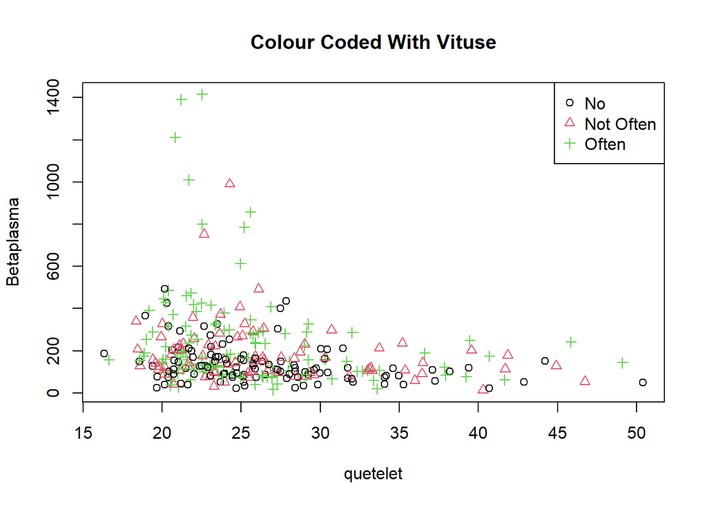

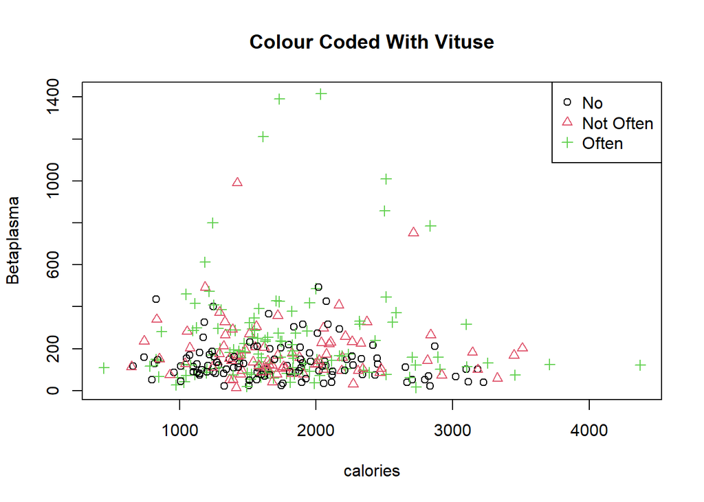

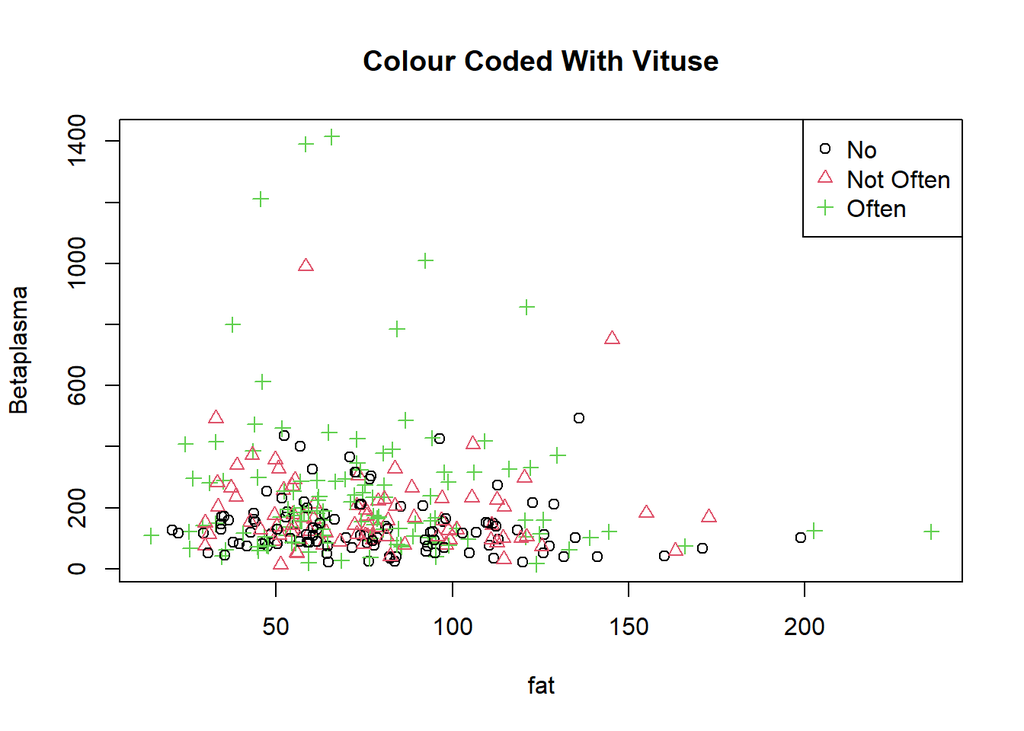

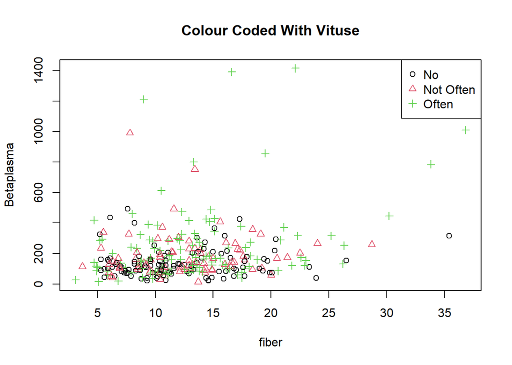

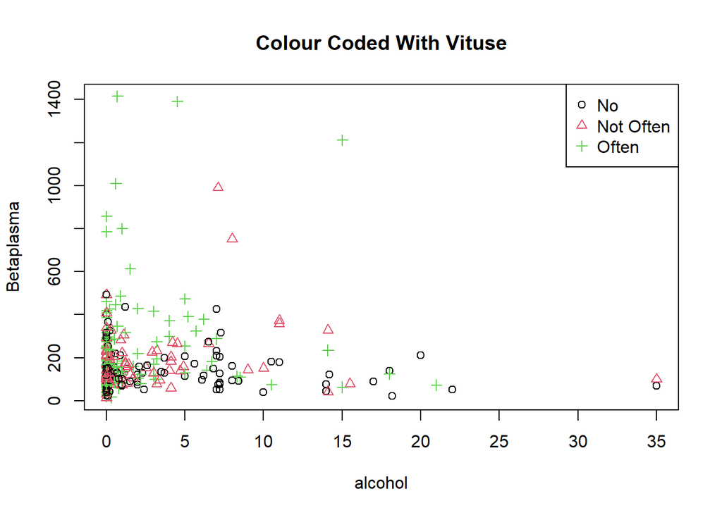

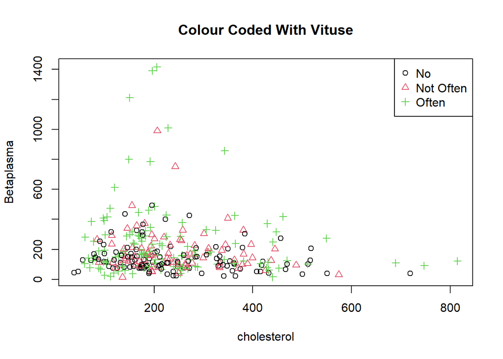

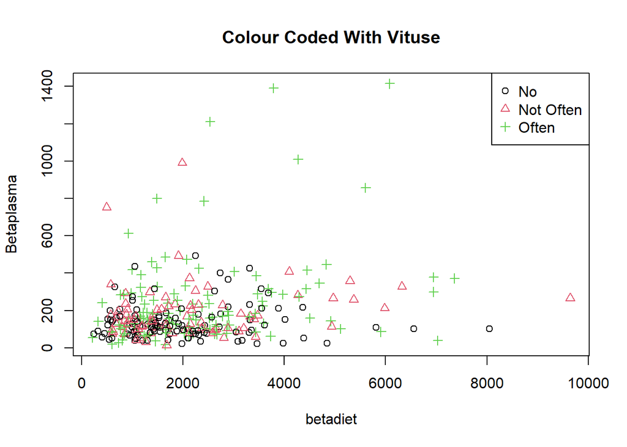

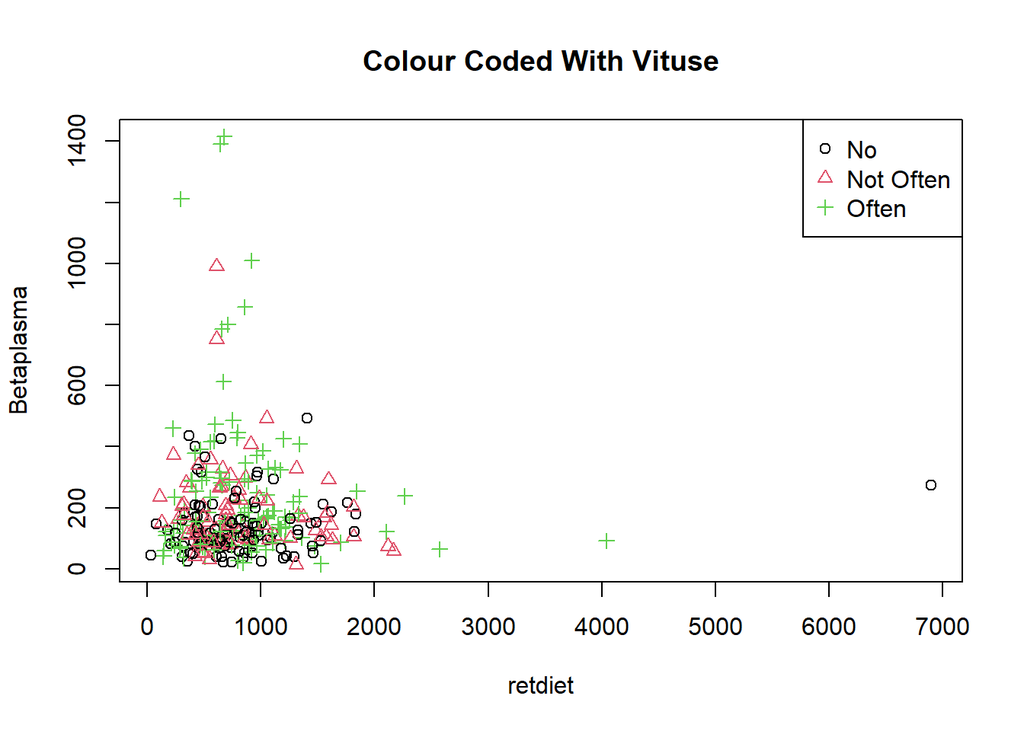

```r
for(i in c(1,4,6:12)){
  plot(data[,i], data$betaplasma, pch = as.integer(data$vituse), col = as.integer(data$vituse), main = "Colour Coded With Vituse",ylab = "Betaplasma", xlab = paste(names(data)[i]))
legend('topright', legend = c("No","Not Often", "Often"),pch=c(1,2,3),col=c(1,2,3))
}
```

- The above plots do not visually suggest a need for interaction terms of each of the categorical variables with the quantitative variables.

```r
y = data$betaplasma

#categorical predictor variables
X_c = data[, c(2,3,5)]
colnames(X_c) = c("sex","smokstat","vituse")

#quantitative predictor variables
X_q = data[, c(1,4,6:12)]
colnames(X_q) = c("age","quetelet","calories","fat","fiber","alcohol", "cholesterol", "betadiet", "retdiet")


# new dataset
d = cbind(y,X_q,X_c)
str(d)
```

```
## 'data.frame':    313 obs. of  13 variables:
##  $ y          : int  200 124 328 153 92 148 258 64 218 81 ...
##  $ age        : int  64 76 38 40 72 40 65 58 35 55 ...
##  $ quetelet   : num  21.5 23.9 20 25.1 21 ...
##  $ calories   : num  1299 1032 2372 2450 1952 ...
##  $ fat        : num  57 50.1 83.6 97.5 82.6 56 52 63.4 57.8 39.6 ...
##  $ fiber      : num  6.3 15.8 19.1 26.5 16.2 9.6 28.7 10.9 20.3 15.5 ...
##  $ alcohol    : num  0 0 14.1 0.5 0 1.3 0 0 0.6 0 ...
##  $ cholesterol: num  170.3 75.8 257.9 332.6 170.8 ...
##  $ betadiet   : int  1945 2653 6321 1061 2863 1729 5371 823 2895 3307 ...
##  $ retdiet    : int  890 451 660 864 1209 1439 802 2571 944 493 ...
##  $ sex        : Factor w/ 2 levels "FEMALE","MALE": 1 1 1 1 1 1 1 1 1 1 ...
##  $ smokstat   : Factor w/ 3 levels "CURRENT","FORMER",..: 2 3 2 2 3 2 3 3 3 2 ...
##  $ vituse     : Factor w/ 3 levels "NO","NOT OFTEN",..: 3 3 2 1 3 1 2 3 1 1 ...
```

**Data Splitting**

```r
set.seed(100)
n_split = nrow(d)*0.8
ind = sample(1:n, n_split, replace=FALSE)
train = d[ind, ]
valid = d[-ind, ]
```

**Preliminary Model Fitting**

```r
fit1 = lm(y~., train)
summary(fit1)
```

```
##
## Call:
## lm(formula = y ~ ., data = train)
##
## Residuals:
##     Min      1Q  Median      3Q     Max
## -263.61  -87.46  -26.24   38.16 1075.32
##
## Coefficients:
##                   Estimate Std. Error t value Pr(>|t|)
## (Intercept)     165.831596  77.583838   2.137  0.03360 *
## age               0.416565   0.876529   0.475  0.63506
## quetelet         -5.179757   1.836353  -2.821  0.00520 **
## calories         -0.067786   0.058802  -1.153  0.25018
## fat               0.874541   0.941419   0.929  0.35387
## fiber             9.682010   3.409565   2.840  0.00491 **
## alcohol           1.322578   2.578978   0.513  0.60855
## cholesterol      -0.112758   0.125650  -0.897  0.37043
## betadiet          0.011292   0.008277   1.364  0.17381
## retdiet          -0.010526   0.020726  -0.508  0.61203
## sexMALE         -12.940098  38.077103  -0.340  0.73428
## smokstatFORMER   43.735370  36.141217   1.210  0.22745
## smokstatNEVER    50.987195  34.869301   1.462  0.14502
## vituseNOT OFTEN  40.791480  29.243292   1.395  0.16437
## vituseOFTEN      76.951843  27.030096   2.847  0.00481 **
## ---
## Signif. codes:  0 '***' 0.001 '**' 0.01 '*' 0.05 '.' 0.1 ' ' 1
##
## Residual standard error: 172.9 on 234 degrees of freedom
##   (1 observation deleted due to missingness)
## Multiple R-squared:  0.1979, Adjusted R-squared:  0.1499
## F-statistic: 4.124 on 14 and 234 DF,  p-value: 1.987e-06
```

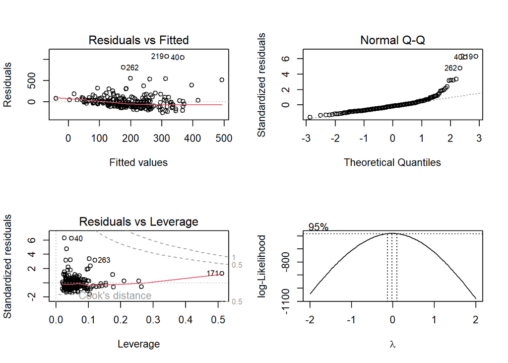

```r
par(mfrow=c(2,2))
plot(fit1, which = 1)
plot(fit1, which = 2)
plot(fit1, which = 5)
boxcox(fit1)
```

The boxcox plot is suggesting a log transformation of the response variable: betaplasma

```r
fit2 = lm(log(y)~., train)
summary(fit2)
```

```
##
## Call:
## lm(formula = log(y) ~ ., data = train)
##
## Residuals:
##      Min       1Q   Median       3Q      Max
## -2.13470 -0.38471 -0.02475  0.39445  1.90390
##
## Coefficients:
##                   Estimate Std. Error t value Pr(>|t|)
## (Intercept)      4.844e+00  3.029e-01  15.990  < 2e-16 ***
## age              4.221e-03  3.422e-03   1.233 0.218644
## quetelet        -2.664e-02  7.170e-03  -3.716 0.000254 ***
## calories        -2.654e-04  2.296e-04  -1.156 0.248845
## fat              3.174e-03  3.676e-03   0.864 0.388710
## fiber            3.479e-02  1.331e-02   2.613 0.009551 **
## alcohol          9.148e-04  1.007e-02   0.091 0.927689
## cholesterol     -5.513e-04  4.906e-04  -1.124 0.262248
## betadiet         3.265e-05  3.232e-05   1.010 0.313447
## retdiet          2.289e-05  8.093e-05   0.283 0.777548
## sexMALE         -1.574e-01  1.487e-01  -1.059 0.290682
## smokstatFORMER   2.922e-01  1.411e-01   2.070 0.039507 *
## smokstatNEVER    3.183e-01  1.361e-01   2.338 0.020221 *
## vituseNOT OFTEN  2.596e-01  1.142e-01   2.274 0.023902 *
## vituseOFTEN      3.168e-01  1.055e-01   3.002 0.002975 **
## ---
## Signif. codes:  0 '***' 0.001 '**' 0.01 '*' 0.05 '.' 0.1 ' ' 1
##
## Residual standard error: 0.6752 on 234 degrees of freedom
##   (1 observation deleted due to missingness)
## Multiple R-squared:  0.2441, Adjusted R-squared:  0.1989
## F-statistic: 5.398 on 14 and 234 DF,  p-value: 6.374e-09
```

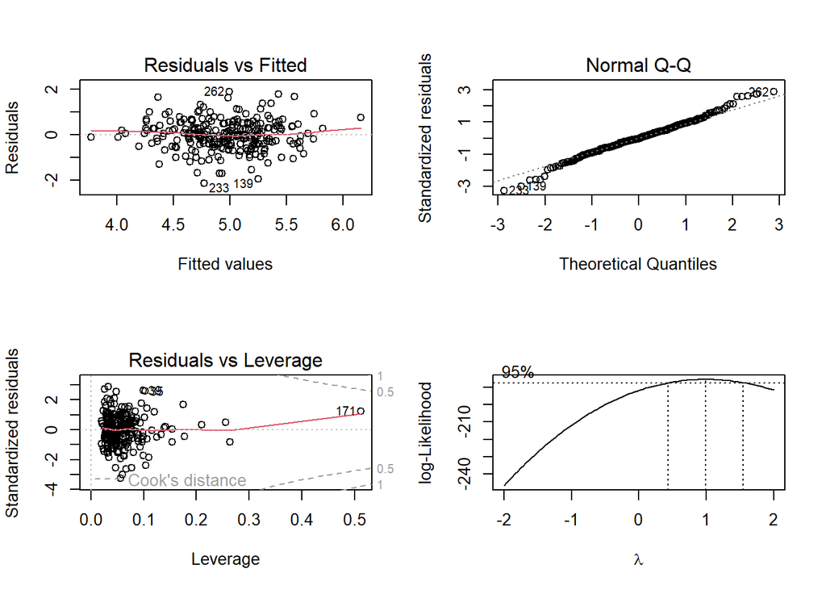

```r
par(mfrow=c(2,2))
plot(fit2, which = 1)
plot(fit2, which = 2)
plot(fit2, which = 5)
boxcox(fit2)
```

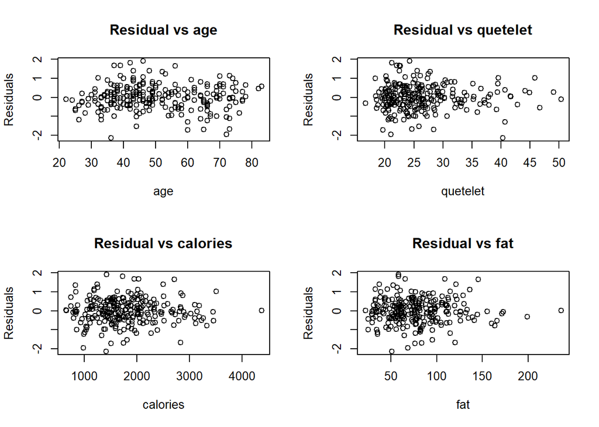

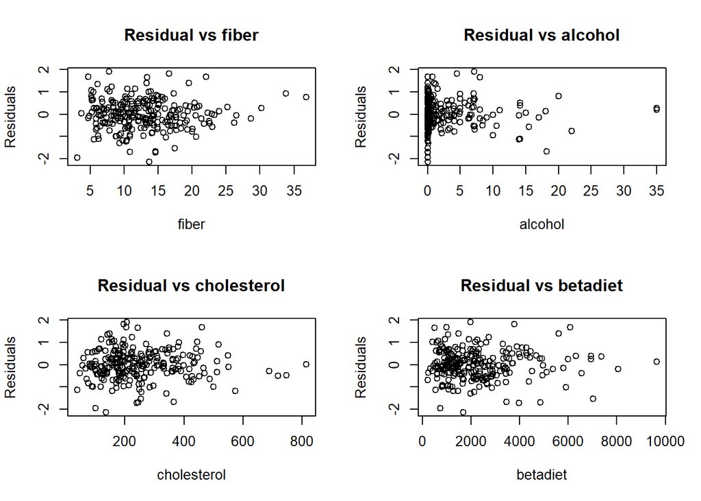

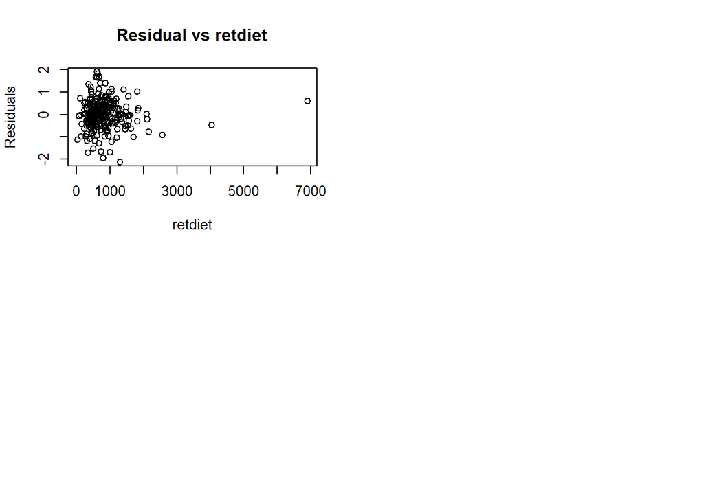

```r
par(mfrow=c(2,2))
for (i in c(2:10)){
  plot(fit2$model[,i], fit2$residuals,
       main = paste("Residual vs",names(fit2$model)[i]),
       xlab = paste(names(fit2$model)[i]),
       ylab = paste("Residuals"))
}
```

- Higher order terms of the predictor variables are not being suggested.

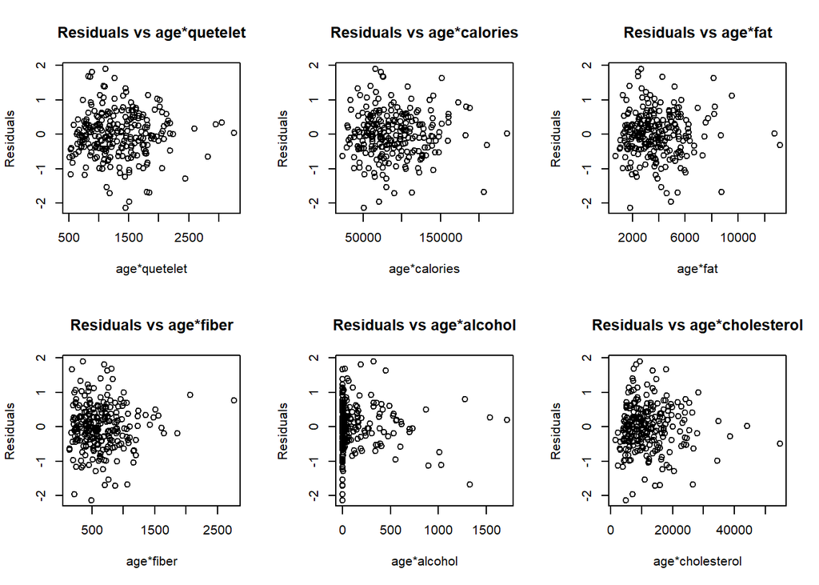

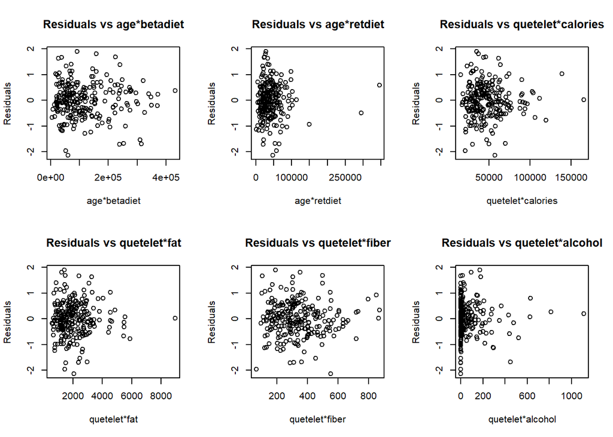

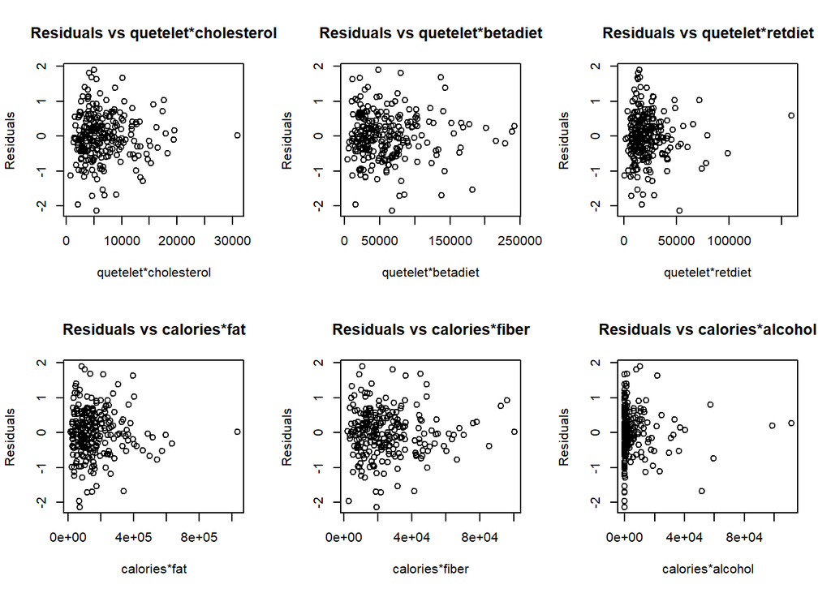

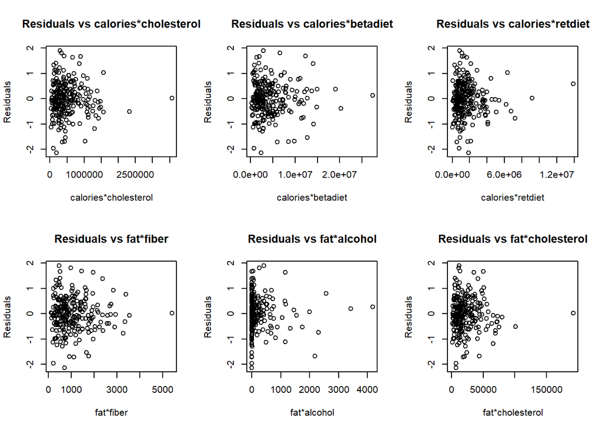

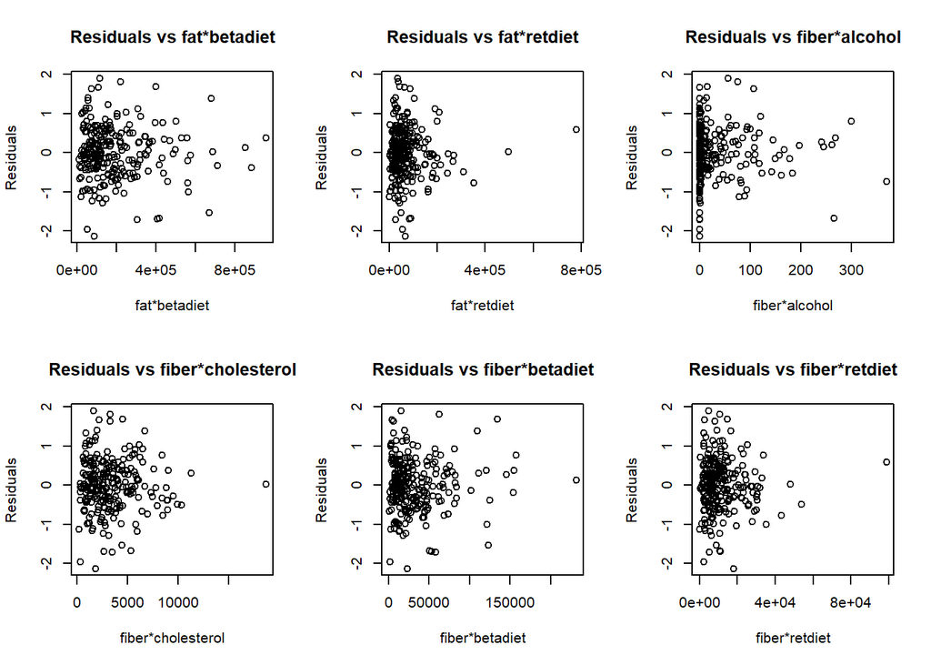

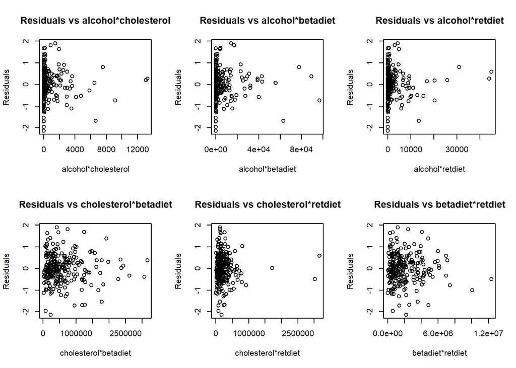

```r
par(mfrow = c(2,3))
for (i in 2:9){
  for (j in (i+1):10){
    plot(fit2$model[, i]*fit2$model[, j], fit2$residuals,
    main = paste0("Residuals vs ", names(fit2$model)[i],"*",names(fit2$model)[j]),
    xlab = paste0(names(fit2$model)[i],"*",names(fit2$model)[j]),
    ylab = "Residuals"
    )
  }
}
```

- Interactions terms are also not being suggested by the above plots.

fitting the model without retdiet in fit3

```r
fit3 = lm(log(y)~age+quetelet+calories+fat+fiber+alcohol+cholesterol+betadiet+sex+smokstat+vituse, train)
summary(fit3)
```

```
##
## Call:
## lm(formula = log(y) ~ age + quetelet + calories + fat + fiber +
##     alcohol + cholesterol + betadiet + sex + smokstat + vituse,
##     data = train)
##
## Residuals:
##      Min       1Q   Median       3Q      Max
## -2.11934 -0.38987 -0.01589  0.39212  1.90392
##
## Coefficients:
##                   Estimate Std. Error t value Pr(>|t|)
## (Intercept)      4.841e+00  3.021e-01  16.023  < 2e-16 ***
## age              4.282e-03  3.409e-03   1.256  0.21040
## quetelet        -2.661e-02  7.155e-03  -3.719  0.00025 ***
## calories        -2.635e-04  2.291e-04  -1.150  0.25112
## fat              3.227e-03  3.664e-03   0.881  0.37929
## fiber            3.516e-02  1.322e-02   2.659  0.00837 **
## alcohol          8.777e-04  1.005e-02   0.087  0.93048
## cholesterol     -5.220e-04  4.786e-04  -1.091  0.27650
## betadiet         3.158e-05  3.204e-05   0.986  0.32522
## sexMALE         -1.596e-01  1.482e-01  -1.077  0.28271
## smokstatFORMER   2.945e-01  1.406e-01   2.095  0.03727 *
## smokstatNEVER    3.212e-01  1.355e-01   2.370  0.01859 *
## vituseNOT OFTEN  2.587e-01  1.139e-01   2.271  0.02404 *
## vituseOFTEN      3.166e-01  1.053e-01   3.006  0.00294 **
## ---
## Signif. codes:  0 '***' 0.001 '**' 0.01 '*' 0.05 '.' 0.1 ' ' 1
##
## Residual standard error: 0.6738 on 235 degrees of freedom
##   (1 observation deleted due to missingness)
## Multiple R-squared:  0.2439, Adjusted R-squared:  0.202
## F-statistic:  5.83 on 13 and 235 DF,  p-value: 2.635e-09
```

```r
anova(fit3,fit2)
```

```
## Analysis of Variance Table
##
## Model 1: log(y) ~ age + quetelet + calories + fat + fiber + alcohol +
##     cholesterol + betadiet + sex + smokstat + vituse
## Model 2: log(y) ~ age + quetelet + calories + fat + fiber + alcohol +
##     cholesterol + betadiet + retdiet + sex + smokstat + vituse
##   Res.Df    RSS Df Sum of Sq    F Pr(>F)
## 1    235 106.70
## 2    234 106.67  1  0.036466 0.08 0.7775
```

- fit3 is better than fit2

Alcohol removed.

```r
fit4 = lm(log(y)~age+quetelet+calories+fat+fiber+cholesterol+betadiet+sex+smokstat+vituse, train)
summary(fit4)
```

```
##
## Call:
## lm(formula = log(y) ~ age + quetelet + calories + fat + fiber +
##     cholesterol + betadiet + sex + smokstat + vituse, data = train)
##
## Residuals:
##      Min       1Q   Median       3Q      Max
## -2.11887 -0.39510 -0.01977  0.39234  1.90659
##
## Coefficients:
##                   Estimate Std. Error t value Pr(>|t|)
## (Intercept)      4.842e+00  3.007e-01  16.103  < 2e-16 ***
## age              4.311e-03  3.385e-03   1.274 0.204070
## quetelet        -2.669e-02  7.081e-03  -3.770 0.000206 ***
## calories        -2.554e-04  2.088e-04  -1.223 0.222565
## fat              3.123e-03  3.458e-03   0.903 0.367278
## fiber            3.479e-02  1.251e-02   2.780 0.005870 **
## cholesterol     -5.241e-04  4.770e-04  -1.099 0.272995
## betadiet         3.175e-05  3.191e-05   0.995 0.320855
## sexMALE         -1.573e-01  1.456e-01  -1.080 0.281099
## smokstatFORMER   2.951e-01  1.401e-01   2.106 0.036295 *
## smokstatNEVER    3.207e-01  1.351e-01   2.373 0.018425 *
## vituseNOT OFTEN  2.579e-01  1.133e-01   2.277 0.023704 *
## vituseOFTEN      3.149e-01  1.032e-01   3.050 0.002551 **
## ---
## Signif. codes:  0 '***' 0.001 '**' 0.01 '*' 0.05 '.' 0.1 ' ' 1
##
## Residual standard error: 0.6724 on 236 degrees of freedom
##   (1 observation deleted due to missingness)
## Multiple R-squared:  0.2438, Adjusted R-squared:  0.2054
## F-statistic: 6.342 on 12 and 236 DF,  p-value: 1.012e-09
```

```r
anova(fit4,fit3)
```

```
## Analysis of Variance Table
##
## Model 1: log(y) ~ age + quetelet + calories + fat + fiber + cholesterol +
##     betadiet + sex + smokstat + vituse
## Model 2: log(y) ~ age + quetelet + calories + fat + fiber + alcohol +
##     cholesterol + betadiet + sex + smokstat + vituse
##   Res.Df   RSS Df Sum of Sq      F Pr(>F)
## 1    236 106.7
## 2    235 106.7  1 0.0034633 0.0076 0.9305
```

- fit4 is better than fit 3

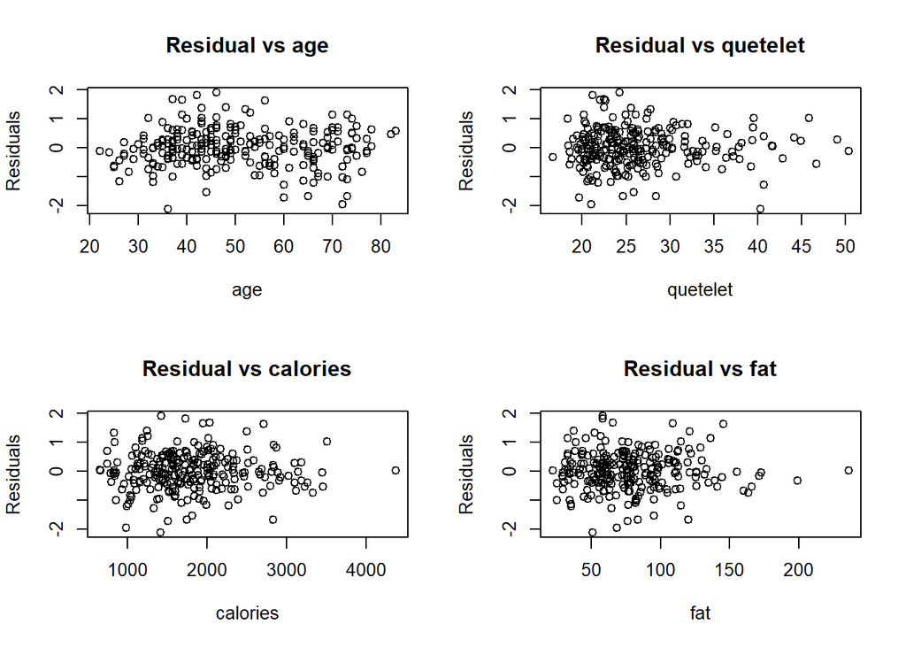

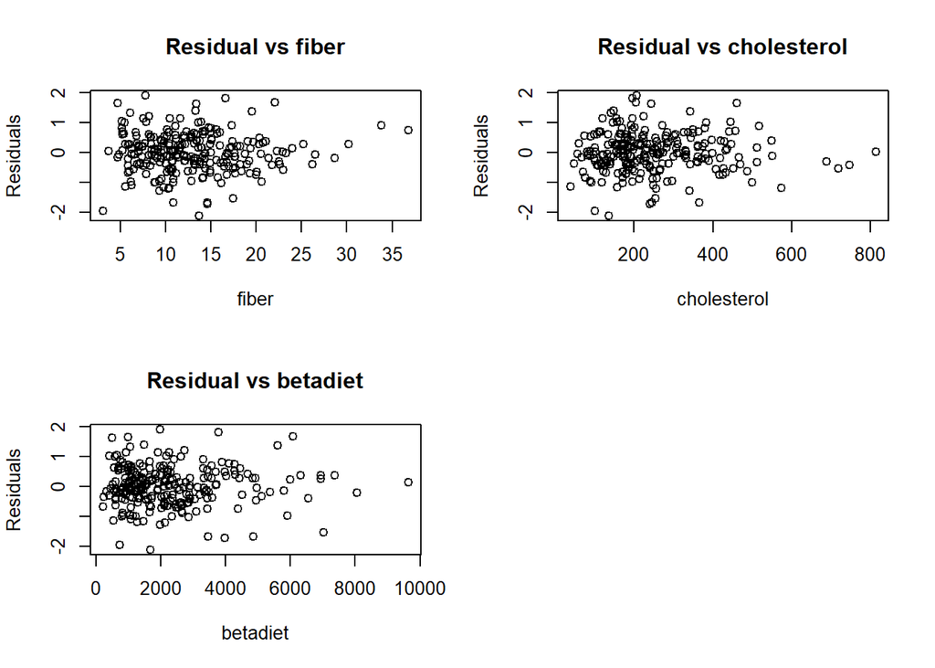

```r
par(mfrow=c(2,2))
for (i in c(2:8)){
  plot(fit4$model[,i], fit4$residuals,
       main = paste("Residual vs",names(fit4$model)[i]),
       xlab = paste(names(fit4$model)[i]),
       ylab = paste("Residuals"))
}
```

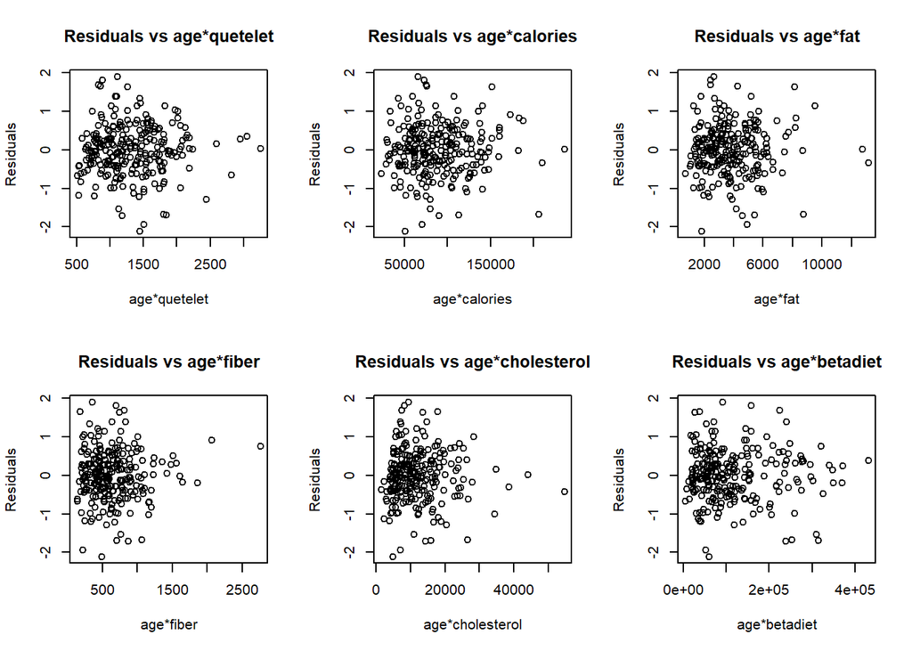

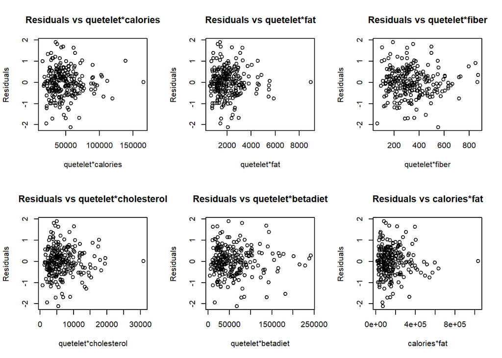

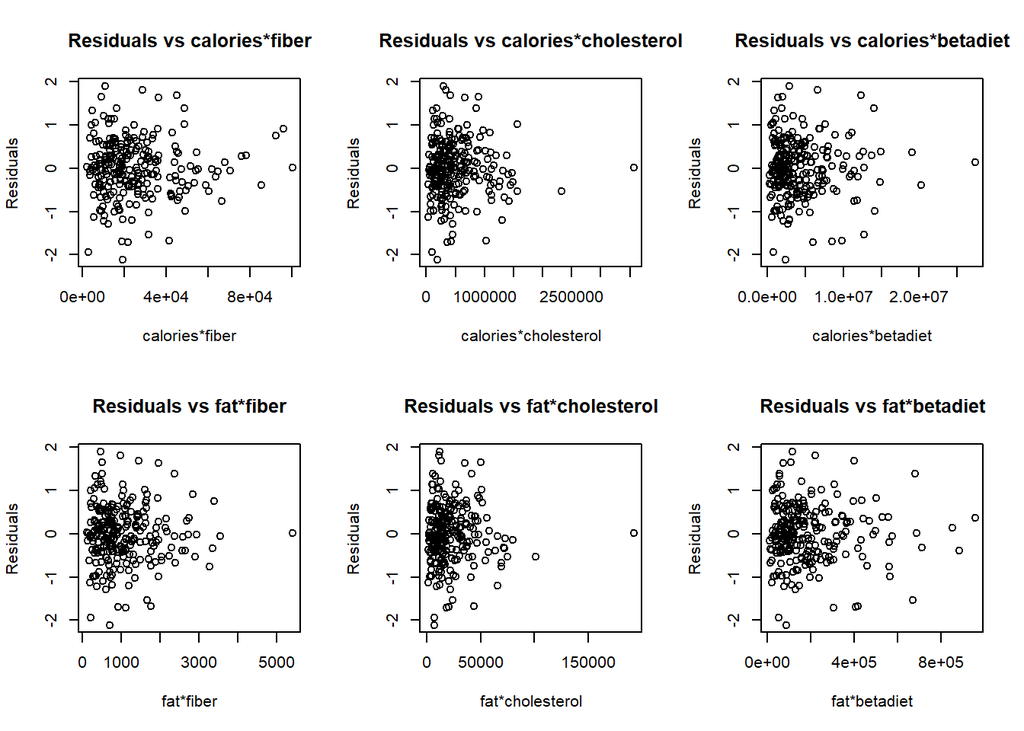

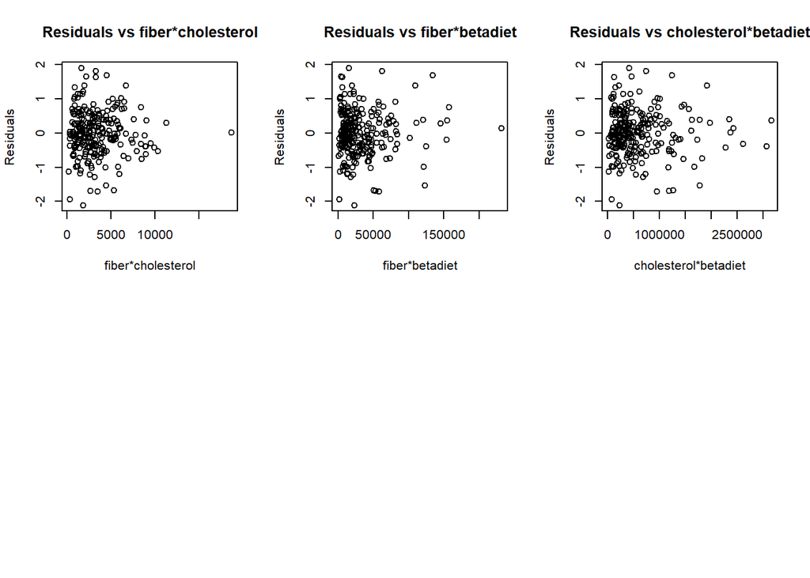

```r
par(mfrow = c(2,3))
for (i in 2:7){
  for (j in (i+1):8){
    plot(fit4$model[, i]*fit4$model[, j], fit4$residuals,
    main = paste0("Residuals vs ", names(fit4$model)[i],"*",names(fit4$model)[j]),
    xlab = paste0(names(fit4$model)[i],"*",names(fit4$model)[j]),
    ylab = "Residuals"
    )
  }
}
```

```r
vif(fit4)
```

```
##                 GVIF Df GVIF^(1/(2*Df))
## age         1.284428  1        1.133326
## quetelet    1.065369  1        1.032167
## calories    9.635637  1        3.104132
## fat         7.193275  1        2.682028
## fiber       2.526908  1        1.589625
## cholesterol 2.070433  1        1.438900
## betadiet    1.371493  1        1.171108
## sex         1.237190  1        1.112290
## smokstat    1.170144  2        1.040064
## vituse      1.136354  2        1.032472
```

- Calories showing highest multicollineariry. So in the following, calories has been removed.

```r
fit5 = lm(log(y)~age+quetelet+fat+fiber+cholesterol+betadiet+sex+smokstat+vituse, train)
summary(fit5)
```

```
##
## Call:
## lm(formula = log(y) ~ age + quetelet + fat + fiber + cholesterol +
##     betadiet + sex + smokstat + vituse, data = train)
##
## Residuals:
##      Min       1Q   Median       3Q      Max
## -2.10196 -0.38609 -0.01347  0.42614  1.88846
##
## Coefficients:
##                   Estimate Std. Error t value Pr(>|t|)
## (Intercept)      4.750e+00  2.914e-01  16.301  < 2e-16 ***
## age              5.350e-03  3.280e-03   1.631 0.104203
## quetelet        -2.644e-02  7.085e-03  -3.732 0.000238 ***
## fat             -4.321e-04  1.874e-03  -0.231 0.817791
## fiber            2.513e-02  9.712e-03   2.587 0.010276 *
## cholesterol     -6.054e-04  4.728e-04  -1.280 0.201667
## betadiet         3.272e-05  3.194e-05   1.025 0.306552
## sexMALE         -1.821e-01  1.443e-01  -1.262 0.208257
## smokstatFORMER   2.964e-01  1.403e-01   2.113 0.035679 *
## smokstatNEVER    3.218e-01  1.353e-01   2.379 0.018159 *
## vituseNOT OFTEN  2.473e-01  1.131e-01   2.187 0.029705 *
## vituseOFTEN      3.090e-01  1.032e-01   2.993 0.003056 **
## ---
## Signif. codes:  0 '***' 0.001 '**' 0.01 '*' 0.05 '.' 0.1 ' ' 1
##
## Residual standard error: 0.6731 on 237 degrees of freedom
##   (1 observation deleted due to missingness)
## Multiple R-squared:  0.2391, Adjusted R-squared:  0.2037
## F-statistic: 6.769 on 11 and 237 DF,  p-value: 7.163e-10
```

- Since fat, calories and cholesterol have high correlation as shown in the pair plot, 3 models with each of them being removed respectively have been formed and compared with fit4 containing all of these three variables.

```r
anova(fit5, fit4)
```

```
## Analysis of Variance Table
##
## Model 1: log(y) ~ age + quetelet + fat + fiber + cholesterol + betadiet +
##     sex + smokstat + vituse
## Model 2: log(y) ~ age + quetelet + calories + fat + fiber + cholesterol +
##     betadiet + sex + smokstat + vituse
##   Res.Df    RSS Df Sum of Sq      F Pr(>F)
## 1    237 107.38
## 2    236 106.70  1   0.67623 1.4956 0.2226
```

```r
fit6 = lm(log(y)~age+quetelet+calories+fat+fiber+betadiet+sex+smokstat+vituse, train)
summary(fit6)
```

```
##
## Call:
## lm(formula = log(y) ~ age + quetelet + calories + fat + fiber +
##     betadiet + sex + smokstat + vituse, data = train)
##
## Residuals:
##      Min       1Q   Median       3Q      Max
## -2.08703 -0.38591 -0.00461  0.37583  1.90122
##
## Coefficients:
##                   Estimate Std. Error t value Pr(>|t|)
## (Intercept)      4.841e+00  3.008e-01  16.091  < 2e-16 ***
## age              4.479e-03  3.383e-03   1.324 0.186809
## quetelet        -2.755e-02  7.041e-03  -3.912 0.000119 ***
## calories        -2.874e-04  2.069e-04  -1.389 0.166122
## fat              2.276e-03  3.372e-03   0.675 0.500396
## fiber            3.628e-02  1.245e-02   2.915 0.003903 **
## betadiet         2.933e-05  3.185e-05   0.921 0.358003
## sexMALE         -1.857e-01  1.434e-01  -1.295 0.196415
## smokstatFORMER   2.979e-01  1.402e-01   2.125 0.034640 *
## smokstatNEVER    3.228e-01  1.352e-01   2.388 0.017723 *
## vituseNOT OFTEN  2.552e-01  1.133e-01   2.252 0.025222 *
## vituseOFTEN      3.118e-01  1.033e-01   3.019 0.002810 **
## ---
## Signif. codes:  0 '***' 0.001 '**' 0.01 '*' 0.05 '.' 0.1 ' ' 1
##
## Residual standard error: 0.6727 on 237 degrees of freedom
##   (1 observation deleted due to missingness)
## Multiple R-squared:   0.24,  Adjusted R-squared:  0.2047
## F-statistic: 6.803 on 11 and 237 DF,  p-value: 6.307e-10
```

```r
anova(fit6, fit4)
```

```
## Analysis of Variance Table
##
## Model 1: log(y) ~ age + quetelet + calories + fat + fiber + betadiet +
##     sex + smokstat + vituse
## Model 2: log(y) ~ age + quetelet + calories + fat + fiber + cholesterol +
##     betadiet + sex + smokstat + vituse
##   Res.Df    RSS Df Sum of Sq      F Pr(>F)
## 1    237 107.25
## 2    236 106.70  1   0.54585 1.2073  0.273
```

```r
fit7 = lm(log(y)~age+quetelet+calories+fiber+cholesterol+betadiet+sex+smokstat+vituse, train)
summary(fit7)
```

```
##
## Call:
## lm(formula = log(y) ~ age + quetelet + calories + fiber + cholesterol +
##     betadiet + sex + smokstat + vituse, data = train)
##
## Residuals:
##      Min       1Q   Median       3Q      Max
## -2.11909 -0.39887  0.00394  0.40133  1.88576
##
## Coefficients:
##                   Estimate Std. Error t value Pr(>|t|)
## (Intercept)      4.815e+00  2.991e-01  16.099  < 2e-16 ***
## age              4.810e-03  3.339e-03   1.441  0.15102
## quetelet        -2.646e-02  7.073e-03  -3.741  0.00023 ***
## calories        -9.677e-05  1.130e-04  -0.856  0.39261
## fiber            3.000e-02  1.133e-02   2.648  0.00864 **
## cholesterol     -4.280e-04  4.648e-04  -0.921  0.35810
## betadiet         3.180e-05  3.190e-05   0.997  0.31989
## sexMALE         -1.711e-01  1.447e-01  -1.182  0.23849
## smokstatFORMER   2.954e-01  1.401e-01   2.109  0.03601 *
## smokstatNEVER    3.158e-01  1.350e-01   2.340  0.02012 *
## vituseNOT OFTEN  2.505e-01  1.129e-01   2.218  0.02748 *
## vituseOFTEN      3.080e-01  1.029e-01   2.993  0.00306 **
## ---
## Signif. codes:  0 '***' 0.001 '**' 0.01 '*' 0.05 '.' 0.1 ' ' 1
##
## Residual standard error: 0.6722 on 237 degrees of freedom
##   (1 observation deleted due to missingness)
## Multiple R-squared:  0.2412, Adjusted R-squared:  0.206
## F-statistic:  6.85 on 11 and 237 DF,  p-value: 5.305e-10
```

```r
anova(fit7, fit4)
```

```
## Analysis of Variance Table
##
## Model 1: log(y) ~ age + quetelet + calories + fiber + cholesterol + betadiet +
##     sex + smokstat + vituse
## Model 2: log(y) ~ age + quetelet + calories + fat + fiber + cholesterol +
##     betadiet + sex + smokstat + vituse
##   Res.Df    RSS Df Sum of Sq     F Pr(>F)
## 1    237 107.07
## 2    236 106.70  1   0.36894 0.816 0.3673
```

```r
vif(fit7)
```

```
##                 GVIF Df GVIF^(1/(2*Df))
## age         1.250316  1        1.118175
## quetelet    1.063913  1        1.031461
## calories    2.823335  1        1.680278
## fiber       2.073441  1        1.439945
## cholesterol 1.967373  1        1.402631
## betadiet    1.371489  1        1.171106
## sex         1.223652  1        1.106188
## smokstat    1.165326  2        1.038991
## vituse      1.128233  2        1.030623
```

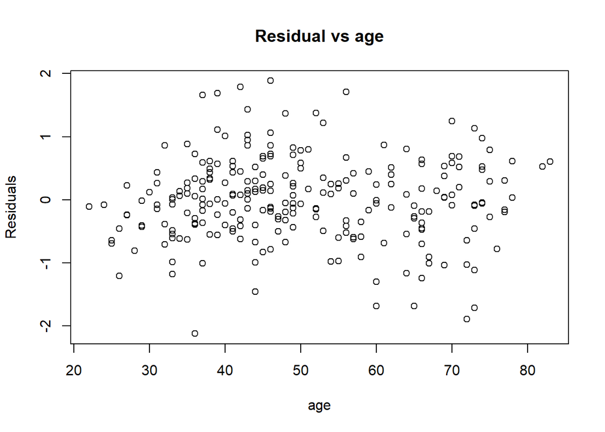

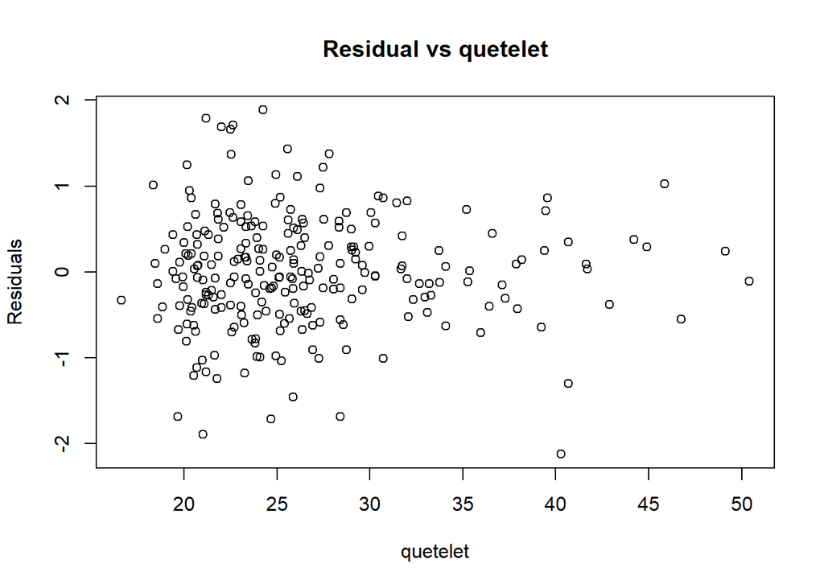

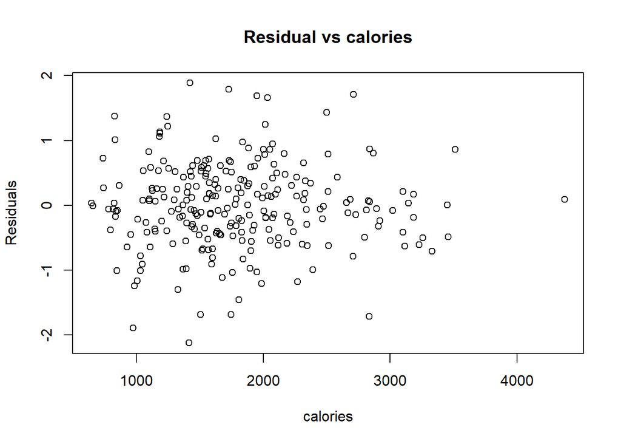

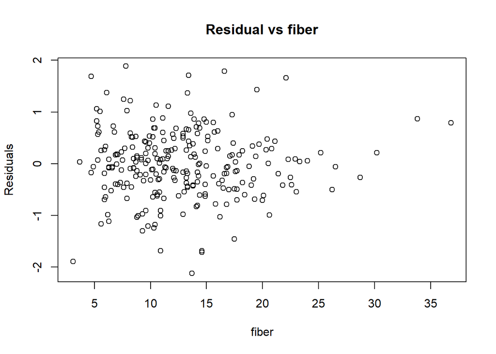

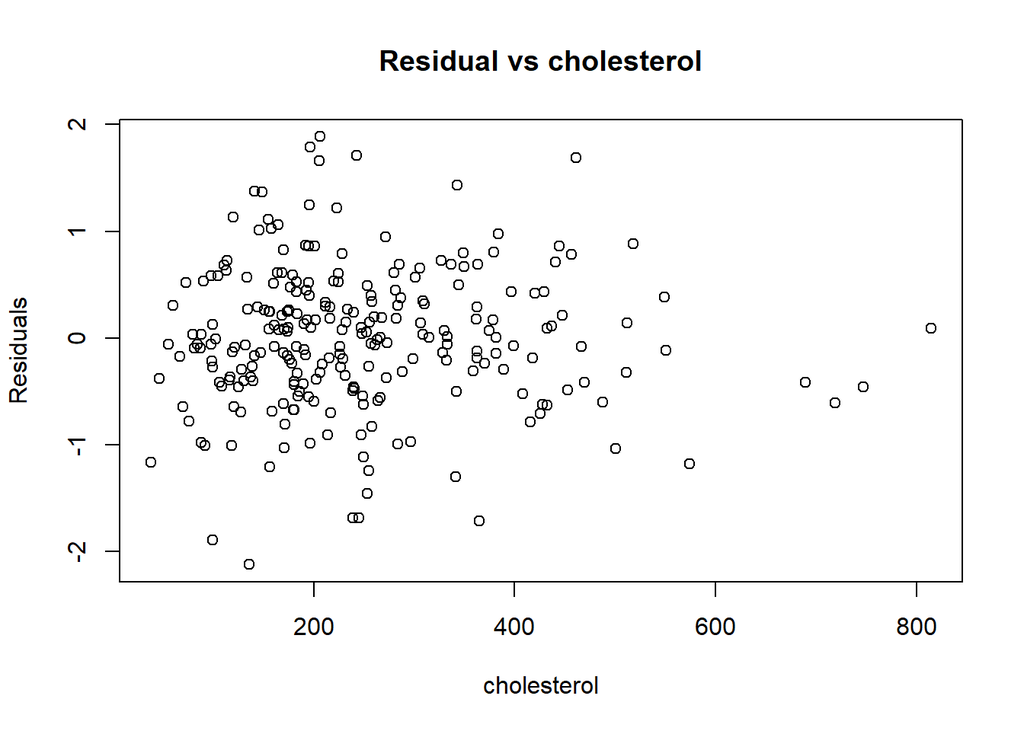

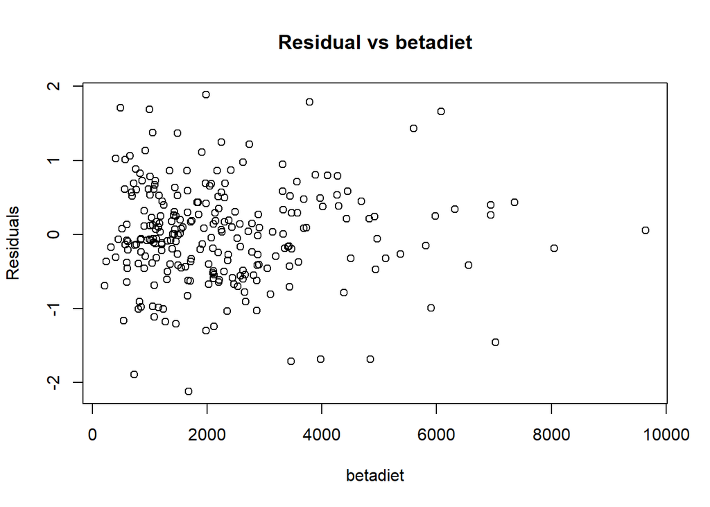

```r
# par(mfrow=c(2,2))
for (i in c(2:7)){
  plot(fit7$model[,i], fit7$residuals,
       main = paste("Residual vs",names(fit7$model)[i]),
       xlab = paste(names(fit7$model)[i]),
       ylab = paste("Residuals"))
}
```

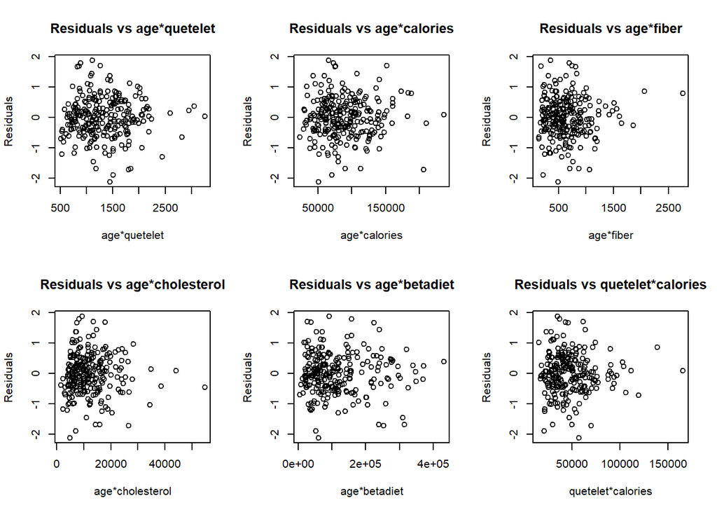

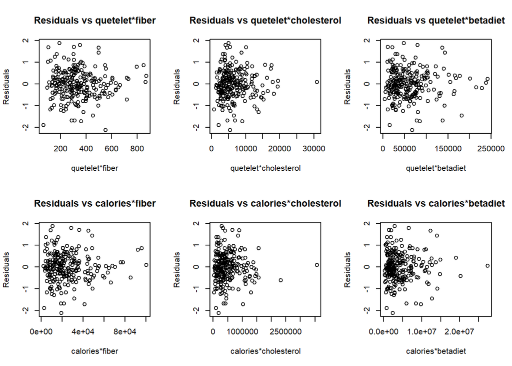

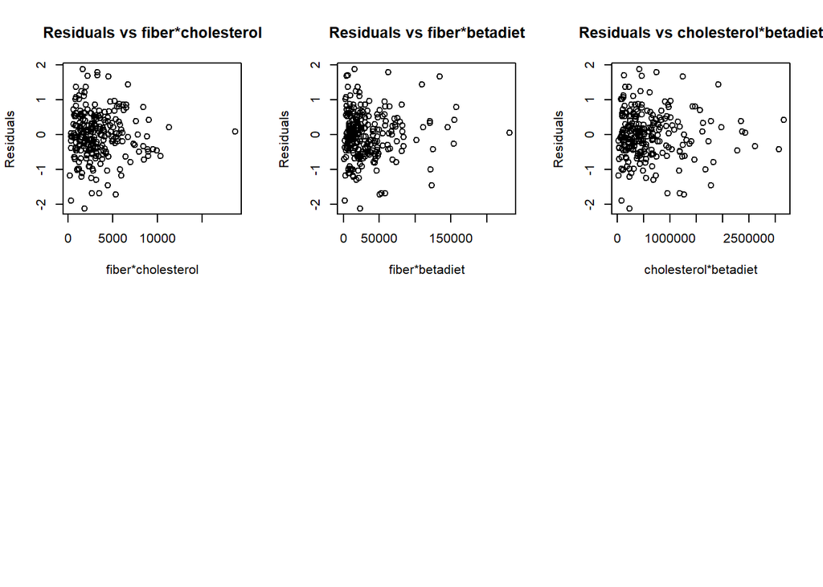

```r
par(mfrow = c(2,3))
for (i in 2:6){
  for (j in (i+1):7){
    plot(fit7$model[, i]*fit7$model[, j], fit7$residuals,
    main = paste0("Residuals vs ", names(fit7$model)[i],"*",names(fit7$model)[j]),
    xlab = paste0(names(fit7$model)[i],"*",names(fit7$model)[j]),
    ylab = "Residuals"
    )
  }
}
```

**Model Selection**

- The following three models are used as upper models to conduct AIC and BIC proceedures

```r
fit0 = lm(log(y)~1, train)
```

```r
fit_upper = lm(log(y) ~ (.)^2 + I(age^2) + I(quetelet^2) + I(calories^2) + I(fat^2) + I(fiber^2) + I(alcohol^2) + I(cholesterol^2) + I(betadiet^2) + I(retdiet^2), data = train)
summary(fit_upper)
```

```
##
## Call:
## lm(formula = log(y) ~ (.)^2 + I(age^2) + I(quetelet^2) + I(calories^2) +
##     I(fat^2) + I(fiber^2) + I(alcohol^2) + I(cholesterol^2) +
##     I(betadiet^2) + I(retdiet^2), data = train)
##
## Residuals:
##      Min       1Q   Median       3Q      Max
## -1.44657 -0.30745  0.01693  0.27736  1.58140
##
## Coefficients:
##                                  Estimate Std. Error t value Pr(>|t|)
## (Intercept)                     5.410e+00  2.344e+00   2.308   0.0225 *
## age                             7.437e-03  4.497e-02   0.165   0.8689
## quetelet                       -5.964e-02  8.724e-02  -0.684   0.4954
## calories                       -2.534e-03  2.480e-03  -1.022   0.3086
## fat                             2.688e-02  4.102e-02   0.655   0.5134
## fiber                           5.033e-02  1.306e-01   0.385   0.7006
## alcohol                        -2.142e-02  1.914e-01  -0.112   0.9111
## cholesterol                     5.955e-03  5.993e-03   0.994   0.3222
## betadiet                        3.681e-04  4.196e-04   0.877   0.3819
## retdiet                         2.022e-04  1.541e-03   0.131   0.8958
## sexMALE                         9.947e-01  2.419e+00   0.411   0.6815
## smokstatFORMER                 -1.744e-01  1.905e+00  -0.092   0.9272
## smokstatNEVER                  -3.643e-01  1.766e+00  -0.206   0.8369
## vituseNOT OFTEN                 5.925e-01  1.026e+00   0.578   0.5645
## vituseOFTEN                    -5.687e-01  1.006e+00  -0.565   0.5729
## I(age^2)                       -2.032e-04  3.143e-04  -0.647   0.5190
## I(quetelet^2)                   2.679e-04  1.115e-03   0.240   0.8104
## I(calories^2)                   1.379e-06  1.136e-06   1.214   0.2270
## I(fat^2)                        5.069e-04  3.344e-04   1.516   0.1319
## I(fiber^2)                      1.247e-04  2.961e-03   0.042   0.9665
## I(alcohol^2)                    4.248e-04  3.961e-03   0.107   0.9147
## I(cholesterol^2)               -7.858e-06  5.164e-06  -1.522   0.1304
## I(betadiet^2)                  -1.014e-08  1.963e-08  -0.517   0.6062
## I(retdiet^2)                   -3.164e-08  1.351e-07  -0.234   0.8151
## age:quetelet                    5.333e-04  7.461e-04   0.715   0.4760
## age:calories                    3.586e-05  2.902e-05   1.236   0.2186
## age:fat                        -5.655e-04  4.442e-04  -1.273   0.2051
## age:fiber                       7.194e-04  1.478e-03   0.487   0.6273
```

[output cut: 77 more lines]

```
## sexMALE:smokstatFORMER         -1.201e+00  9.308e-01  -1.291   0.1990
## sexMALE:smokstatNEVER          -7.617e-01  7.884e-01  -0.966   0.3357
## sexMALE:vituseNOT OFTEN         1.058e+00  7.148e-01   1.480   0.1412
## sexMALE:vituseOFTEN             5.700e-01  6.071e-01   0.939   0.3495
## smokstatFORMER:vituseNOT OFTEN  7.166e-01  4.409e-01   1.625   0.1064
## smokstatNEVER:vituseNOT OFTEN  -1.410e-01  4.302e-01  -0.328   0.7436
## smokstatFORMER:vituseOFTEN      7.790e-01  5.295e-01   1.471   0.1436
## smokstatNEVER:vituseOFTEN       3.446e-01  5.122e-01   0.673   0.5022
## ---
## Signif. codes:  0 '***' 0.001 '**' 0.01 '*' 0.05 '.' 0.1 ' ' 1
##
## Residual standard error: 0.6641 on 136 degrees of freedom
##   (1 observation deleted due to missingness)
## Multiple R-squared:  0.5749, Adjusted R-squared:  0.2248
## F-statistic: 1.642 on 112 and 136 DF,  p-value: 0.002914
```

```r
fit_upper1 = lm(log(y) ~ .^2, data = train)
summary(fit_upper1)
```

```
##
## Call:
## lm(formula = log(y) ~ .^2, data = train)
##
## Residuals:
##      Min       1Q   Median       3Q      Max
## -1.50676 -0.31007  0.02864  0.26223  1.59499
##
## Coefficients:
##                                  Estimate Std. Error t value Pr(>|t|)
## (Intercept)                     6.238e+00  1.941e+00   3.213  0.00162 **
## age                            -1.529e-02  2.881e-02  -0.531  0.59651
## quetelet                       -4.876e-02  5.432e-02  -0.898  0.37080
## calories                       -3.703e-03  2.112e-03  -1.753  0.08164 .
## fat                             3.783e-02  3.850e-02   0.983  0.32739
## fiber                           7.197e-02  1.166e-01   0.617  0.53800
## alcohol                         4.019e-02  1.754e-01   0.229  0.81905
## cholesterol                     4.554e-03  5.672e-03   0.803  0.42329
## betadiet                        3.692e-04  3.774e-04   0.978  0.32957
## retdiet                         5.494e-04  1.449e-03   0.379  0.70522
## sexMALE                         1.232e+00  2.279e+00   0.541  0.58957
## smokstatFORMER                 -4.928e-01  1.841e+00  -0.268  0.78934
## smokstatNEVER                  -4.280e-01  1.685e+00  -0.254  0.79986
## vituseNOT OFTEN                 3.647e-01  9.873e-01   0.369  0.71234
## vituseOFTEN                    -2.876e-01  9.598e-01  -0.300  0.76493
## age:quetelet                    4.663e-04  7.115e-04   0.655  0.51328
## age:calories                    2.392e-05  2.472e-05   0.967  0.33494
## age:fat                        -2.550e-04  3.709e-04  -0.688  0.49283
## age:fiber                       1.166e-03  1.292e-03   0.903  0.36809
## age:alcohol                    -9.318e-04  1.308e-03  -0.712  0.47740
## age:cholesterol                -9.719e-05  5.908e-05  -1.645  0.10212
## age:betadiet                   -9.595e-06  3.942e-06  -2.434  0.01616 *
## age:retdiet                     2.331e-05  1.416e-05   1.646  0.10194
## age:sexMALE                     3.915e-02  1.860e-02   2.105  0.03702 *
## age:smokstatFORMER             -3.028e-03  1.802e-02  -0.168  0.86681
## age:smokstatNEVER               8.039e-04  1.781e-02   0.045  0.96407
## age:vituseNOT OFTEN             3.366e-03  1.198e-02   0.281  0.77907
## age:vituseOFTEN                -1.419e-02  1.028e-02  -1.381  0.16942
## quetelet:calories               8.601e-05  6.223e-05   1.382  0.16905
## quetelet:fat                   -1.044e-03  1.020e-03  -1.024  0.30770
```

[output cut: 66 more lines]

```
## sexMALE:smokstatFORMER         -1.344e+00  8.866e-01  -1.516  0.13178
## sexMALE:smokstatNEVER          -6.310e-01  7.652e-01  -0.825  0.41094
## sexMALE:vituseNOT OFTEN         6.231e-01  6.608e-01   0.943  0.34731
## sexMALE:vituseOFTEN             5.024e-01  5.779e-01   0.869  0.38611
## smokstatFORMER:vituseNOT OFTEN  6.788e-01  4.337e-01   1.565  0.11970
## smokstatNEVER:vituseNOT OFTEN  -1.311e-01  4.172e-01  -0.314  0.75381
## smokstatFORMER:vituseOFTEN      8.785e-01  5.131e-01   1.712  0.08903 .
## smokstatNEVER:vituseOFTEN       4.479e-01  4.910e-01   0.912  0.36326
## ---
## Signif. codes:  0 '***' 0.001 '**' 0.01 '*' 0.05 '.' 0.1 ' ' 1
##
## Residual standard error: 0.6566 on 145 degrees of freedom
##   (1 observation deleted due to missingness)
## Multiple R-squared:  0.5571, Adjusted R-squared:  0.2424
## F-statistic:  1.77 on 103 and 145 DF,  p-value: 0.0007675
```

```r
fit2
```

```
##
## Call:
## lm(formula = log(y) ~ ., data = train)
##
## Coefficients:
##     (Intercept)              age         quetelet         calories
##       4.844e+00        4.221e-03       -2.664e-02       -2.654e-04
##             fat            fiber          alcohol      cholesterol
##       3.174e-03        3.479e-02        9.148e-04       -5.513e-04
##        betadiet          retdiet          sexMALE   smokstatFORMER
##       3.265e-05        2.289e-05       -1.574e-01        2.922e-01
##   smokstatNEVER  vituseNOT OFTEN      vituseOFTEN
##       3.183e-01        2.596e-01        3.168e-01
```

```r
summary(fit2)
```

```
##
## Call:
## lm(formula = log(y) ~ ., data = train)
##
## Residuals:
##      Min       1Q   Median       3Q      Max
## -2.13470 -0.38471 -0.02475  0.39445  1.90390
##
## Coefficients:
##                   Estimate Std. Error t value Pr(>|t|)
## (Intercept)      4.844e+00  3.029e-01  15.990  < 2e-16 ***
## age              4.221e-03  3.422e-03   1.233 0.218644
## quetelet        -2.664e-02  7.170e-03  -3.716 0.000254 ***
## calories        -2.654e-04  2.296e-04  -1.156 0.248845
## fat              3.174e-03  3.676e-03   0.864 0.388710
## fiber            3.479e-02  1.331e-02   2.613 0.009551 **
## alcohol          9.148e-04  1.007e-02   0.091 0.927689
## cholesterol     -5.513e-04  4.906e-04  -1.124 0.262248
## betadiet         3.265e-05  3.232e-05   1.010 0.313447
## retdiet          2.289e-05  8.093e-05   0.283 0.777548
## sexMALE         -1.574e-01  1.487e-01  -1.059 0.290682
## smokstatFORMER   2.922e-01  1.411e-01   2.070 0.039507 *
## smokstatNEVER    3.183e-01  1.361e-01   2.338 0.020221 *
## vituseNOT OFTEN  2.596e-01  1.142e-01   2.274 0.023902 *
## vituseOFTEN      3.168e-01  1.055e-01   3.002 0.002975 **
## ---
## Signif. codes:  0 '***' 0.001 '**' 0.01 '*' 0.05 '.' 0.1 ' ' 1
##
## Residual standard error: 0.6752 on 234 degrees of freedom
##   (1 observation deleted due to missingness)
## Multiple R-squared:  0.2441, Adjusted R-squared:  0.1989
## F-statistic: 5.398 on 14 and 234 DF,  p-value: 6.374e-09
```

**Model Selection**

```r
step_f1.1 = stepAIC(fit0, scope = list(upper = fit_upper, lower = ~1), trace = TRUE, direction = "both", k = 2)
```

```
## Start:  AIC=-139.4
## log(y) ~ 1
##
##                    Df Sum of Sq    RSS     AIC
## + I(fiber^2)        1   11.7313 129.38 -159.01
## + fiber             1    9.9223 131.19 -155.56
## + vituse            2   10.6706 130.44 -154.98
## + quetelet          1    9.3400 131.78 -154.45
## + I(quetelet^2)     1    8.9415 132.17 -153.70
## + smokstat          2    6.8490 134.27 -147.79
## + betadiet          1    5.4658 135.65 -147.24
## + I(betadiet^2)     1    4.4187 136.70 -145.32
## + I(cholesterol^2)  1    3.8156 137.30 -144.23
## + cholesterol       1    2.9830 138.13 -142.72
## + age               1    2.8084 138.31 -142.41
## + I(age^2)          1    2.2531 138.86 -141.41
## + I(alcohol^2)      1    2.0996 139.01 -141.13
## + sex               1    1.9844 139.13 -140.93
## + I(fat^2)          1    1.2461 139.87 -139.61
## <none>                          141.12 -139.40
## + fat               1    1.0707 140.04 -139.30
## + alcohol           1    0.9414 140.17 -139.07
## + I(calories^2)     1    0.2674 140.85 -137.87
## + calories          1    0.0757 141.04 -137.53
## + I(retdiet^2)      1    0.0424 141.07 -137.48
## + retdiet           1    0.0002 141.12 -137.40
##
## Step:  AIC=-159.01
## log(y) ~ I(fiber^2)
##
##                    Df Sum of Sq    RSS     AIC
## + quetelet          1    7.1521 122.23 -171.17
## + I(quetelet^2)     1    6.9661 122.42 -170.79
## + vituse            2    7.5745 121.81 -170.03
## + I(calories^2)     1    6.1230 123.26 -169.08
## + I(cholesterol^2)  1    5.5408 123.84 -167.91
## + calories          1    5.3401 124.04 -167.51
## + cholesterol       1    5.0246 124.36 -166.88
## + I(fat^2)          1    3.9631 125.42 -164.76
## + fat               1    3.9070 125.48 -164.65
```

[output cut: 169 more lines]

```
## + age                1    0.3390 101.27 -196.01
## + I(age^2)           1    0.1537 101.46 -195.55
## + I(retdiet^2)       1    0.1502 101.46 -195.54
## + fiber              1    0.1316 101.48 -195.50
## + I(alcohol^2)       1    0.0565 101.56 -195.32
## + I(quetelet^2)      1    0.0458 101.57 -195.29
## + sex                1    0.0409 101.57 -195.28
## + retdiet            1    0.0263 101.58 -195.24
## + calories           1    0.0037 101.61 -195.19
## + alcohol            1    0.0016 101.61 -195.18
## + quetelet:vituse    2    0.4449 101.17 -194.27
## + quetelet:smokstat  2    0.1955 101.42 -193.66
## - vituse:smokstat    4    5.3445 106.96 -192.41
## - quetelet           1    4.8760 106.49 -187.51
## - I(fiber^2)         1    6.8922 108.50 -182.84
```

```r
step_f1.1$anova
```

```
## Stepwise Model Path
## Analysis of Deviance Table
##
## Initial Model:
## log(y) ~ 1
##
## Final Model:
## log(y) ~ I(fiber^2) + quetelet + vituse + I(calories^2) + smokstat +
##     I(cholesterol^2) + vituse:smokstat
##
##
##                 Step Df   Deviance Resid. Df Resid. Dev       AIC
## 1                                        248   141.1151 -139.4014
## 2       + I(fiber^2)  1 11.7312755       247   129.3838 -159.0128
## 3         + quetelet  1  7.1521304       246   122.2317 -171.1722
## 4           + vituse  2  6.6121442       244   115.6195 -181.0199
## 5    + I(calories^2)  1  4.1262832       243   111.4932 -188.0688
## 6         + smokstat  2  3.7964764       241   107.6968 -192.6952
## 7  + smokstat:vituse  4  5.1697114       237   102.5270 -196.9442
## 8 + I(cholesterol^2)  1  0.9152802       236   101.6118 -197.1771
```

```r
summary(lm(log(y) ~ I(fiber^2) + quetelet + vituse + I(calories^2) + smokstat + I(cholesterol^2) + vituse:smokstat, train))
```

```
##
## Call:
## lm(formula = log(y) ~ I(fiber^2) + quetelet + vituse + I(calories^2) +
##     smokstat + I(cholesterol^2) + vituse:smokstat, data = train)
##
## Residuals:
##      Min       1Q   Median       3Q      Max
## -2.03503 -0.42514 -0.00563  0.40279  1.84476
##
## Coefficients:
##                                  Estimate Std. Error t value Pr(>|t|)
## (Intercept)                     5.133e+00  2.496e-01  20.563  < 2e-16 ***
## I(fiber^2)                      1.166e-03  2.915e-04   4.001 8.45e-05 ***
## quetelet                       -2.329e-02  6.920e-03  -3.365 0.000893 ***
## vituseNOT OFTEN                 3.341e-01  2.659e-01   1.257 0.210087
## vituseOFTEN                    -1.468e-01  2.741e-01  -0.535 0.592855
## I(calories^2)                  -3.211e-08  2.325e-08  -1.381 0.168486
## smokstatFORMER                  6.363e-02  2.014e-01   0.316 0.752312
## smokstatNEVER                   3.716e-01  1.965e-01   1.891 0.059806 .
## I(cholesterol^2)               -8.765e-07  6.012e-07  -1.458 0.146167
## vituseNOT OFTEN:smokstatFORMER  3.012e-01  3.245e-01   0.928 0.354231
## vituseOFTEN:smokstatFORMER      7.272e-01  3.199e-01   2.273 0.023922 *
## vituseNOT OFTEN:smokstatNEVER  -3.644e-01  3.079e-01  -1.184 0.237786
## vituseOFTEN:smokstatNEVER       4.039e-01  3.079e-01   1.312 0.190937
## ---
## Signif. codes:  0 '***' 0.001 '**' 0.01 '*' 0.05 '.' 0.1 ' ' 1
##
## Residual standard error: 0.6562 on 236 degrees of freedom
##   (1 observation deleted due to missingness)
## Multiple R-squared:  0.2799, Adjusted R-squared:  0.2433
## F-statistic: 7.646 on 12 and 236 DF,  p-value: 6.138e-12
```

```r
step_f1.2 = stepAIC(fit0, scope = list(upper = fit_upper1, lower = ~1), trace = TRUE, direction = "both", k = 2)
```

```
## Start:  AIC=-139.4
## log(y) ~ 1
##
##               Df Sum of Sq    RSS     AIC
## + fiber        1    9.9223 131.19 -155.56
## + vituse       2   10.6706 130.44 -154.98
## + quetelet     1    9.3400 131.78 -154.45
## + smokstat     2    6.8490 134.27 -147.79
## + betadiet     1    5.4658 135.65 -147.24
## + cholesterol  1    2.9830 138.13 -142.72
## + age          1    2.8084 138.31 -142.41
## + sex          1    1.9844 139.13 -140.93
## <none>                     141.12 -139.40
## + fat          1    1.0707 140.04 -139.30
## + alcohol      1    0.9414 140.17 -139.07
## + calories     1    0.0757 141.04 -137.53
## + retdiet      1    0.0002 141.12 -137.40
##
## Step:  AIC=-155.56
## log(y) ~ fiber
##
##               Df Sum of Sq    RSS     AIC
## + quetelet     1    7.6361 123.56 -168.49
## + vituse       2    7.7867 123.41 -166.79
## + calories     1    6.0119 125.18 -165.24
## + cholesterol  1    5.7746 125.42 -164.76
## + fat          1    4.4899 126.70 -162.23
## + smokstat     2    4.5390 126.65 -160.32
## + age          1    2.4772 128.72 -158.30
## + sex          1    2.0602 129.13 -157.50
## <none>                     131.19 -155.56
## + betadiet     1    0.8051 130.39 -155.09
## + alcohol      1    0.7504 130.44 -154.98
## + retdiet      1    0.5794 130.61 -154.66
## - fiber        1    9.9223 141.12 -139.40
##
## Step:  AIC=-168.49
## log(y) ~ fiber + quetelet
##
##                  Df Sum of Sq    RSS     AIC
```

[output cut: 155 more lines]

```
## + betadiet:smokstat  2    0.9028  98.840 -196.06
## + fiber:vituse       2    0.8863  98.856 -196.02
## + quetelet:calories  1    0.0630  99.680 -195.96
## + calories:fiber     1    0.0225  99.720 -195.86
## + retdiet            1    0.0010  99.742 -195.80
## + alcohol            1    0.0009  99.742 -195.80
## + calories:betadiet  1    0.0005  99.742 -195.80
## + quetelet:vituse    2    0.5245  99.218 -195.11
## + calories:smokstat  2    0.4001  99.343 -194.80
## + quetelet:smokstat  2    0.2078  99.535 -194.32
## + calories:vituse    2    0.0533  99.689 -193.93
## - fiber:smokstat     2    3.8829 103.626 -192.29
## - calories           1    3.2035 102.946 -191.93
## - vituse:smokstat    4    5.9007 105.643 -191.49
## - quetelet           1    5.6351 105.378 -186.12
```

```r
step_f1.2$anova
```

```
## Stepwise Model Path
## Analysis of Deviance Table
##
## Initial Model:
## log(y) ~ 1
##
## Final Model:
## log(y) ~ fiber + quetelet + vituse + calories + smokstat + betadiet +
##     vituse:smokstat + fiber:smokstat
##
##
##                Step Df  Deviance Resid. Df Resid. Dev       AIC
## 1                                      248  141.11507 -139.4014
## 2           + fiber  1 9.9223278       247  131.19274 -155.5556
## 3        + quetelet  1 7.6360848       246  123.55665 -168.4875
## 4          + vituse  2 6.7277810       244  116.82887 -178.4289
## 5        + calories  1 4.1003301       243  112.72854 -185.3251
## 6        + smokstat  2 3.4469313       241  109.28161 -189.0577
## 7 + smokstat:vituse  4 5.0402683       237  104.24134 -192.8153
## 8  + fiber:smokstat  2 3.6883717       235  100.55297 -197.7853
## 9        + betadiet  1 0.8102915       234   99.74268 -197.7999
```

```r
summary(lm(log(y) ~ fiber + quetelet + vituse + calories + smokstat + betadiet + vituse:smokstat + fiber:smokstat, train))
```

```
##
## Call:
## lm(formula = log(y) ~ fiber + quetelet + vituse + calories +
##     smokstat + betadiet + vituse:smokstat + fiber:smokstat, data = train)
##
## Residuals:
##      Min       1Q   Median       3Q      Max
## -2.01978 -0.40029 -0.01274  0.41822  1.66512
##
## Coefficients:
##                                  Estimate Std. Error t value Pr(>|t|)
## (Intercept)                     5.677e+00  3.769e-01  15.064  < 2e-16 ***
## fiber                          -1.579e-02  2.493e-02  -0.633 0.527136
## quetelet                       -2.491e-02  6.850e-03  -3.636 0.000341 ***
## vituseNOT OFTEN                 2.488e-01  2.707e-01   0.919 0.359067
## vituseOFTEN                    -2.152e-01  2.756e-01  -0.781 0.435547
## calories                       -2.248e-04  8.199e-05  -2.741 0.006590 **
## smokstatFORMER                 -3.011e-01  3.843e-01  -0.784 0.434056
## smokstatNEVER                  -4.271e-01  3.636e-01  -1.174 0.241413
## betadiet                        4.286e-05  3.109e-05   1.379 0.169286
## vituseNOT OFTEN:smokstatFORMER  4.155e-01  3.292e-01   1.262 0.208102
## vituseOFTEN:smokstatFORMER      7.834e-01  3.200e-01   2.448 0.015090 *
## vituseNOT OFTEN:smokstatNEVER  -3.165e-01  3.120e-01  -1.014 0.311424
## vituseOFTEN:smokstatNEVER       4.128e-01  3.087e-01   1.337 0.182378
## fiber:smokstatFORMER            3.170e-02  2.802e-02   1.131 0.259078
## fiber:smokstatNEVER             6.880e-02  2.641e-02   2.605 0.009785 **
## ---
## Signif. codes:  0 '***' 0.001 '**' 0.01 '*' 0.05 '.' 0.1 ' ' 1
##
## Residual standard error: 0.6529 on 234 degrees of freedom
##   (1 observation deleted due to missingness)
## Multiple R-squared:  0.2932, Adjusted R-squared:  0.2509
## F-statistic: 6.933 on 14 and 234 DF,  p-value: 7.17e-12
```

```r
step_f1.3 = stepAIC(fit0, scope = list(upper = fit2, lower = ~1), trace = TRUE, direction = "both", k = 2)
```

```
## Start:  AIC=-139.4
## log(y) ~ 1
##
##               Df Sum of Sq    RSS     AIC
## + fiber        1    9.9223 131.19 -155.56
## + vituse       2   10.6706 130.44 -154.98
## + quetelet     1    9.3400 131.78 -154.45
## + smokstat     2    6.8490 134.27 -147.79
## + betadiet     1    5.4658 135.65 -147.24
## + cholesterol  1    2.9830 138.13 -142.72
## + age          1    2.8084 138.31 -142.41
## + sex          1    1.9844 139.13 -140.93
## <none>                     141.12 -139.40
## + fat          1    1.0707 140.04 -139.30
## + alcohol      1    0.9414 140.17 -139.07
## + calories     1    0.0757 141.04 -137.53
## + retdiet      1    0.0002 141.12 -137.40
##
## Step:  AIC=-155.56
## log(y) ~ fiber
##
##               Df Sum of Sq    RSS     AIC
## + quetelet     1    7.6361 123.56 -168.49
## + vituse       2    7.7867 123.41 -166.79
## + calories     1    6.0119 125.18 -165.24
## + cholesterol  1    5.7746 125.42 -164.76
## + fat          1    4.4899 126.70 -162.23
## + smokstat     2    4.5390 126.65 -160.32
## + age          1    2.4772 128.72 -158.30
## + sex          1    2.0602 129.13 -157.50
## <none>                     131.19 -155.56
## + betadiet     1    0.8051 130.39 -155.09
## + alcohol      1    0.7504 130.44 -154.98
## + retdiet      1    0.5794 130.61 -154.66
## - fiber        1    9.9223 141.12 -139.40
##
## Step:  AIC=-168.49
## log(y) ~ fiber + quetelet
##
##               Df Sum of Sq    RSS     AIC
```

[output cut: 52 more lines]

```
##
##               Df Sum of Sq    RSS     AIC
## <none>                     109.28 -189.06
## + age          1    0.6146 108.67 -188.46
## + betadiet     1    0.4576 108.82 -188.10
## + cholesterol  1    0.4540 108.83 -188.09
## + fat          1    0.4010 108.88 -187.97
## + sex          1    0.4006 108.88 -187.97
## + alcohol      1    0.0140 109.27 -187.09
## + retdiet      1    0.0064 109.28 -187.07
## - smokstat     2    3.4469 112.73 -185.32
## - calories     1    2.9350 112.22 -184.46
## - vituse       2    5.1808 114.46 -181.52
## - quetelet     1    6.6169 115.90 -176.42
## - fiber        1    7.1482 116.43 -175.28
```

```r
step_f1.3$anova
```

```
## Stepwise Model Path
## Analysis of Deviance Table
##
## Initial Model:
## log(y) ~ 1
##
## Final Model:
## log(y) ~ fiber + quetelet + vituse + calories + smokstat
##
##
##         Step Df Deviance Resid. Df Resid. Dev       AIC
## 1                              248   141.1151 -139.4014
## 2    + fiber  1 9.922328       247   131.1927 -155.5556
## 3 + quetelet  1 7.636085       246   123.5567 -168.4875
## 4   + vituse  2 6.727781       244   116.8289 -178.4289
## 5 + calories  1 4.100330       243   112.7285 -185.3251
## 6 + smokstat  2 3.446931       241   109.2816 -189.0577
```

```r
fit7.1 = lm(log(y) ~ fiber + quetelet + vituse + calories + smokstat, train)
```

```r
summary(fit7.1)
```

```
##
## Call:
## lm(formula = log(y) ~ fiber + quetelet + vituse + calories +
##     smokstat, data = train)
##
## Residuals:
##     Min      1Q  Median      3Q     Max
## -2.1854 -0.4309  0.0166  0.4155  1.9015
##
## Coefficients:
##                   Estimate Std. Error t value Pr(>|t|)
## (Intercept)      5.050e+00  2.491e-01  20.268  < 2e-16 ***
## fiber            3.966e-02  9.989e-03   3.970 9.48e-05 ***
## quetelet        -2.680e-02  7.016e-03  -3.820  0.00017 ***
## vituseNOT OFTEN  2.551e-01  1.112e-01   2.294  0.02265 *
## vituseOFTEN      3.344e-01  1.021e-01   3.277  0.00120 **
## calories        -2.133e-04  8.386e-05  -2.544  0.01158 *
## smokstatFORMER   3.359e-01  1.378e-01   2.438  0.01550 *
## smokstatNEVER    3.581e-01  1.335e-01   2.682  0.00782 **
## ---
## Signif. codes:  0 '***' 0.001 '**' 0.01 '*' 0.05 '.' 0.1 ' ' 1
##
## Residual standard error: 0.6734 on 241 degrees of freedom
##   (1 observation deleted due to missingness)
## Multiple R-squared:  0.2256, Adjusted R-squared:  0.2031
## F-statistic: 10.03 on 7 and 241 DF,  p-value: 5.395e-11
```

```r
anova(fit7.1, fit7)
```

```
## Analysis of Variance Table
##
## Model 1: log(y) ~ fiber + quetelet + vituse + calories + smokstat
## Model 2: log(y) ~ age + quetelet + calories + fiber + cholesterol + betadiet +
##     sex + smokstat + vituse
##   Res.Df    RSS Df Sum of Sq      F Pr(>F)
## 1    241 109.28
## 2    237 107.07  4    2.2078 1.2217 0.3022
```

Using AIC fit7.1 seems to be the best model so far

2. Using stepwise selection and BIC criterion

```r
step_f2 = stepAIC(fit0, scope = list(upper = fit_upper, lower = ~1), trace = TRUE, direction = "both", k=log(n))
```

```
## Start:  AIC=-135.65
## log(y) ~ 1
##
##                    Df Sum of Sq    RSS     AIC
## + I(fiber^2)        1   11.7313 129.38 -151.51
## + fiber             1    9.9223 131.19 -148.05
## + quetelet          1    9.3400 131.78 -146.95
## + I(quetelet^2)     1    8.9415 132.17 -146.20
## + vituse            2   10.6706 130.44 -143.72
## + betadiet          1    5.4658 135.65 -139.73
## + I(betadiet^2)     1    4.4187 136.70 -137.82
## + I(cholesterol^2)  1    3.8156 137.30 -136.72
## + smokstat          2    6.8490 134.27 -136.53
## <none>                          141.12 -135.65
## + cholesterol       1    2.9830 138.13 -135.22
## + age               1    2.8084 138.31 -134.90
## + I(age^2)          1    2.2531 138.86 -133.90
## + I(alcohol^2)      1    2.0996 139.01 -133.63
## + sex               1    1.9844 139.13 -133.42
## + I(fat^2)          1    1.2461 139.87 -132.10
## + fat               1    1.0707 140.04 -131.79
## + alcohol           1    0.9414 140.17 -131.56
## + I(calories^2)     1    0.2674 140.85 -130.37
## + calories          1    0.0757 141.04 -130.03
## + I(retdiet^2)      1    0.0424 141.07 -129.97
## + retdiet           1    0.0002 141.12 -129.90
##
## Step:  AIC=-151.51
## log(y) ~ I(fiber^2)
##
##                    Df Sum of Sq    RSS     AIC
## + quetelet          1    7.1521 122.23 -159.91
## + I(quetelet^2)     1    6.9661 122.42 -159.54
## + I(calories^2)     1    6.1230 123.26 -157.83
## + I(cholesterol^2)  1    5.5408 123.84 -156.65
## + calories          1    5.3401 124.04 -156.25
## + cholesterol       1    5.0246 124.36 -155.62
## + vituse            2    7.5745 121.81 -155.02
## + I(fat^2)          1    3.9631 125.42 -153.50
## + fat               1    3.9070 125.48 -153.39
```

[output cut: 80 more lines]

```
## + I(betadiet^2)     1    0.6531 110.84 -161.26
## + I(fat^2)          1    0.6234 110.87 -161.20
## + fat               1    0.4772 111.02 -160.87
## + sex               1    0.3981 111.09 -160.69
## + cholesterol       1    0.3373 111.16 -160.56
## - quetelet          1    4.9888 116.48 -160.41
## + I(retdiet^2)      1    0.1662 111.33 -160.17
## + I(quetelet^2)     1    0.1287 111.36 -160.09
## + retdiet           1    0.1148 111.38 -160.06
## + I(alcohol^2)      1    0.1033 111.39 -160.03
## + calories          1    0.0171 111.48 -159.84
## + alcohol           1    0.0035 111.49 -159.81
## + fiber             1    0.0005 111.49 -159.80
## + quetelet:vituse   2    0.4422 111.05 -155.04
## - I(fiber^2)        1   11.0332 122.53 -147.81
```

```r
step_f2$anova
```

```
## Stepwise Model Path
## Analysis of Deviance Table
##
## Initial Model:
## log(y) ~ 1
##
## Final Model:
## log(y) ~ I(fiber^2) + quetelet + I(calories^2) + vituse
##
##
##              Step Df  Deviance Resid. Df Resid. Dev       AIC
## 1                                    248   141.1151 -135.6489
## 2    + I(fiber^2)  1 11.731275       247   129.3838 -151.5076
## 3      + quetelet  1  7.152130       246   122.2317 -159.9144
## 4 + I(calories^2)  1  4.654219       245   117.5774 -163.8283
## 5        + vituse  2  6.084208       243   111.4932 -165.5533
```

```r
fit8 = lm(log(y) ~ I(fiber^2) + quetelet + I(calories^2) +
    vituse, data = train)
summary(fit8)
```

```
##
## Call:
## lm(formula = log(y) ~ I(fiber^2) + quetelet + I(calories^2) +
##     vituse, data = train)
##
## Residuals:
##      Min       1Q   Median       3Q      Max
## -2.14656 -0.40563  0.01166  0.39452  1.91997
##
## Coefficients:
##                   Estimate Std. Error t value Pr(>|t|)
## (Intercept)      5.296e+00  2.102e-01  25.199  < 2e-16 ***
## I(fiber^2)       1.406e-03  2.867e-04   4.904 1.72e-06 ***
## quetelet        -2.319e-02  7.031e-03  -3.297 0.001122 **
## I(calories^2)   -5.614e-08  1.872e-08  -2.999 0.002991 **
## vituseNOT OFTEN  2.721e-01  1.115e-01   2.440 0.015417 *
## vituseOFTEN      3.603e-01  1.019e-01   3.537 0.000485 ***
## ---
## Signif. codes:  0 '***' 0.001 '**' 0.01 '*' 0.05 '.' 0.1 ' ' 1
##
## Residual standard error: 0.6774 on 243 degrees of freedom
##   (1 observation deleted due to missingness)
## Multiple R-squared:  0.2099, Adjusted R-squared:  0.1937
## F-statistic: 12.91 on 5 and 243 DF,  p-value: 3.805e-11
```

```r
step_f2.1 = stepAIC(fit0, scope = list(upper = fit_upper1, lower = ~1), trace = TRUE, direction = "both", k = log(n))
```

```
## Start:  AIC=-135.65
## log(y) ~ 1
##
##               Df Sum of Sq    RSS     AIC
## + fiber        1    9.9223 131.19 -148.05
## + quetelet     1    9.3400 131.78 -146.95
## + vituse       2   10.6706 130.44 -143.72
## + betadiet     1    5.4658 135.65 -139.73
## + smokstat     2    6.8490 134.27 -136.53
## <none>                     141.12 -135.65
## + cholesterol  1    2.9830 138.13 -135.22
## + age          1    2.8084 138.31 -134.90
## + sex          1    1.9844 139.13 -133.42
## + fat          1    1.0707 140.04 -131.79
## + alcohol      1    0.9414 140.17 -131.56
## + calories     1    0.0757 141.04 -130.03
## + retdiet      1    0.0002 141.12 -129.90
##
## Step:  AIC=-148.05
## log(y) ~ fiber
##
##               Df Sum of Sq    RSS     AIC
## + quetelet     1    7.6361 123.56 -157.23
## + calories     1    6.0119 125.18 -153.98
## + cholesterol  1    5.7746 125.42 -153.51
## + vituse       2    7.7867 123.41 -151.78
## + fat          1    4.4899 126.70 -150.97
## <none>                     131.19 -148.05
## + age          1    2.4772 128.72 -147.04
## + sex          1    2.0602 129.13 -146.24
## + smokstat     2    4.5390 126.65 -145.31
## + betadiet     1    0.8051 130.39 -143.83
## + alcohol      1    0.7504 130.44 -143.73
## + retdiet      1    0.5794 130.61 -143.40
## - fiber        1    9.9223 141.12 -135.65
##
## Step:  AIC=-157.23
## log(y) ~ fiber + quetelet
##
##                  Df Sum of Sq    RSS     AIC
```

[output cut: 44 more lines]

```
## + smokstat           2    3.4469 109.28 -159.04
## + betadiet           1    0.6275 112.10 -158.45
## + quetelet:fiber     1    0.5905 112.14 -158.37
## + cholesterol        1    0.5085 112.22 -158.18
## + sex                1    0.4163 112.31 -157.98
## + fat                1    0.3878 112.34 -157.91
## + calories:fiber     1    0.2373 112.49 -157.58
## + quetelet:calories  1    0.0513 112.68 -157.17
## + retdiet            1    0.0432 112.69 -157.15
## + alcohol            1    0.0104 112.72 -157.08
## - quetelet           1    5.6934 118.42 -156.29
## + fiber:vituse       2    1.3209 111.41 -154.24
## + calories:vituse    2    0.9970 111.73 -153.52
## + quetelet:vituse    2    0.3799 112.35 -152.15
## - fiber              1    9.9078 122.64 -147.59
```

```r
step_f2.1$anova
```

```
## Stepwise Model Path
## Analysis of Deviance Table
##
## Initial Model:
## log(y) ~ 1
##
## Final Model:
## log(y) ~ fiber + quetelet + calories + vituse
##
##
##         Step Df Deviance Resid. Df Resid. Dev       AIC
## 1                              248   141.1151 -135.6489
## 2    + fiber  1 9.922328       247   131.1927 -148.0504
## 3 + quetelet  1 7.636085       246   123.5567 -157.2298
## 4 + calories  1 4.853604       245   118.7031 -161.4559
## 5   + vituse  2 5.974507       243   112.7285 -162.8097
```

```r
fit8.1 = lm(log(y) ~ fiber + quetelet + calories + vituse, train)
summary(fit8.1)
```

```
##
## Call:
## lm(formula = log(y) ~ fiber + quetelet + calories + vituse, data = train)
##
## Residuals:
##      Min       1Q   Median       3Q      Max
## -2.17272 -0.40419  0.03922  0.39566  1.96160
##
## Coefficients:
##                   Estimate Std. Error t value Pr(>|t|)
## (Intercept)      5.266e+00  2.389e-01  22.041  < 2e-16 ***
## fiber            4.555e-02  9.856e-03   4.621 6.19e-06 ***
## quetelet        -2.464e-02  7.034e-03  -3.503 0.000547 ***
## calories        -2.472e-04  8.313e-05  -2.973 0.003246 **
## vituseNOT OFTEN  2.640e-01  1.123e-01   2.352 0.019493 *
## vituseOFTEN      3.595e-01  1.026e-01   3.503 0.000547 ***
## ---
## Signif. codes:  0 '***' 0.001 '**' 0.01 '*' 0.05 '.' 0.1 ' ' 1
##
## Residual standard error: 0.6811 on 243 degrees of freedom
##   (1 observation deleted due to missingness)
## Multiple R-squared:  0.2012, Adjusted R-squared:  0.1847
## F-statistic: 12.24 on 5 and 243 DF,  p-value: 1.365e-10
```

```r
anova(fit8.1,fit7.1)
```

```
## Analysis of Variance Table
##
## Model 1: log(y) ~ fiber + quetelet + calories + vituse
## Model 2: log(y) ~ fiber + quetelet + vituse + calories + smokstat
##   Res.Df    RSS Df Sum of Sq      F  Pr(>F)
## 1    243 112.73
## 2    241 109.28  2    3.4469 3.8008 0.02371 *
## ---
## Signif. codes:  0 '***' 0.001 '**' 0.01 '*' 0.05 '.' 0.1 ' ' 1
```

Fit 7.1 is better

```r
step_f2.2 = stepAIC(fit0, scope = list(upper = fit2, lower = ~1), trace = TRUE, direction = "both", k = log(n))
```

```
## Start:  AIC=-135.65
## log(y) ~ 1
##
##               Df Sum of Sq    RSS     AIC
## + fiber        1    9.9223 131.19 -148.05
## + quetelet     1    9.3400 131.78 -146.95
## + vituse       2   10.6706 130.44 -143.72
## + betadiet     1    5.4658 135.65 -139.73
## + smokstat     2    6.8490 134.27 -136.53
## <none>                     141.12 -135.65
## + cholesterol  1    2.9830 138.13 -135.22
## + age          1    2.8084 138.31 -134.90
## + sex          1    1.9844 139.13 -133.42
## + fat          1    1.0707 140.04 -131.79
## + alcohol      1    0.9414 140.17 -131.56
## + calories     1    0.0757 141.04 -130.03
## + retdiet      1    0.0002 141.12 -129.90
##
## Step:  AIC=-148.05
## log(y) ~ fiber
##
##               Df Sum of Sq    RSS     AIC
## + quetelet     1    7.6361 123.56 -157.23
## + calories     1    6.0119 125.18 -153.98
## + cholesterol  1    5.7746 125.42 -153.51
## + vituse       2    7.7867 123.41 -151.78
## + fat          1    4.4899 126.70 -150.97
## <none>                     131.19 -148.05
## + age          1    2.4772 128.72 -147.04
## + sex          1    2.0602 129.13 -146.24
## + smokstat     2    4.5390 126.65 -145.31
## + betadiet     1    0.8051 130.39 -143.83
## + alcohol      1    0.7504 130.44 -143.73
## + retdiet      1    0.5794 130.61 -143.40
## - fiber        1    9.9223 141.12 -135.65
##
## Step:  AIC=-157.23
## log(y) ~ fiber + quetelet
##
##               Df Sum of Sq    RSS     AIC
```

[output cut: 34 more lines]

```
##
##               Df Sum of Sq    RSS     AIC
## <none>                     112.73 -162.81
## - vituse       2    5.9745 118.70 -161.46
## - calories     1    4.1003 116.83 -159.67
## + age          1    1.1073 111.62 -159.51
## + smokstat     2    3.4469 109.28 -159.04
## + betadiet     1    0.6275 112.10 -158.45
## + cholesterol  1    0.5085 112.22 -158.18
## + sex          1    0.4163 112.31 -157.98
## + fat          1    0.3878 112.34 -157.91
## + retdiet      1    0.0432 112.69 -157.15
## + alcohol      1    0.0104 112.72 -157.08
## - quetelet     1    5.6934 118.42 -156.29
## - fiber        1    9.9078 122.64 -147.59
```

```r
step_f2.2$anova
```

```
## Stepwise Model Path
## Analysis of Deviance Table
##
## Initial Model:
## log(y) ~ 1
##
## Final Model:
## log(y) ~ fiber + quetelet + calories + vituse
##
##
##         Step Df Deviance Resid. Df Resid. Dev       AIC
## 1                              248   141.1151 -135.6489
## 2    + fiber  1 9.922328       247   131.1927 -148.0504
## 3 + quetelet  1 7.636085       246   123.5567 -157.2298
## 4 + calories  1 4.853604       245   118.7031 -161.4559
## 5   + vituse  2 5.974507       243   112.7285 -162.8097
```

The final model from the above procedure is the same as the model in fit8.1. Therefore, so far fit7.1 from AIC criterion and fit8 from BIC criterion are the best models.

3. Best subset selection procedure

```r
sub_set = regsubsets(log(y) ~ ., data = train, nbest = 1, nvmax = 14, method = 'exhaustive')
sum_sub = summary(sub_set)
n = nrow(train)
# number of coefficients in each model: p
p_m = as.integer(as.numeric(rownames(sum_sub$which)) + 1)
sse = sum_sub$rss
aic = n*log(sse/n) + 2*p_m
bic = n*log(sse/n) + log(n)*p_m
res_sub = cbind(sum_sub$which, sse, sum_sub$rsq, sum_sub$adjr2,p=2:15, sum_sub$cp, aic, bic)
sse1 = sum(fit0$residuals^2)
p = 1
c1 = sse1/(summary(fit0)$sigma^2) - (n-2*p)
aic1 = n*log(sse1/n) + 2*p
bic1 = n*log(sse1/n) + log(n)*p
none = c(1, rep(0,13), sse1, 0, 0, c1, bic1, aic1)
colnames(res_sub) = c(colnames(sum_sub$which),"sse", "Rˆ2", "Rˆ2_a","p", "Cp", "aic", "bic")

res_sub = round(res_sub,5)

for (i in c(17,18)) {
  ind = which(res_sub[, i] == max(as.numeric(res_sub[, i])))
  res_sub[ind, i] = paste0(res_sub[ind, i], '*')
}

for (i in c(16, 21,22)) {
  ind = which(res_sub[, i] == min(as.numeric(res_sub[, i])))
  res_sub[ind, i] = paste0(res_sub[ind, i], '*')
}

ind = which(abs(as.numeric(res_sub[-14,19]) - as.numeric(res_sub[-14, 20])) == min(abs(as.numeric(res_sub[-14,19]) - as.numeric(res_sub[-14, 20]))))
res_sub[ind, 20] = paste0(res_sub[ind, 20], '*')

res_sub = noquote(res_sub)
res_sub
```

```
##    (Intercept) age quetelet calories fat fiber alcohol cholesterol betadiet
## 1  1           0   0        0        0   1     0       0           0
## 2  1           0   1        0        0   1     0       0           0
## 3  1           0   1        1        0   1     0       0           0
## 4  1           0   1        1        0   1     0       0           0
## 5  1           0   1        1        0   1     0       0           0
## 6  1           1   1        1        0   1     0       0           0
## 7  1           0   1        1        0   1     0       0           0
## 8  1           1   1        0        0   1     0       1           0
## 9  1           1   1        1        0   1     0       0           0
## 10 1           1   1        0        0   1     0       1           1
## 11 1           1   1        1        0   1     0       1           1
## 12 1           1   1        1        1   1     0       1           1
## 13 1           1   1        1        1   1     0       1           1
## 14 1           1   1        1        1   1     1       1           1
```

[output cut: 30 more lines]

- Best model

  According to SSE, $R^2$ : the full model

  According to $R^2_a$: intercept, age, quetelet, calories, fiber, sex, smokstat and vituse.

  According to $C_p$ : intercept age, quetelet, calories, fat, fiber, cholesterol, betadiet, retdiet, sex, smokstat and vituse.

  According to AIC: intercept, fiber, quetelet, vituse, calories and smokstat exactly same as fit7.1

  Accroding to BIC: intercept, fiber, quetelet, vituse, calories exactly same as fit8.1

The $C_p$ of fit7.1 is 6.74041 which is close to the number of parameters (8).

```r
p_8 = nrow(summary(fit8)$coeff)
p_8
```

```
## [1] 6
```

```r
sse8 = sum(fit8$residuals^2)
C_p8 = sse8/(summary(fit_upper)$sigma^2) - (n-2*p_8)
C_p8
```

```
## [1] 14.77552
```

```r
# sse_7.1 = anova(step_f1.3)["Residuals",2]
# sse_7.1
#
# mse_2 = sum(summary(fit2)$sigma^2)
#
# cp_7.1 = sse_7.1/mse_2 - (n - 2*p_7.1)
# cp_7.1
```

Therefore, we will consider fit7.1 and fit8 to be the best models.

**Model Validation:**

Internal Validation:

```r
press_7.1 = sum(step_f1.3$residuals^2/(1-influence(step_f1.3)$hat)^2)

sse_7.1 = sum(summary(fit7.1)$residual^2)

cbind(sse_7.1,press_7.1)
```

```
##       sse_7.1 press_7.1
## [1,] 109.2816  116.6734
```

```r
press_8 = sum(step_f2.1$residuals^2/(1-influence(step_f2.1)$hat)^2)

sse_8 = sum(summary(fit8)$residual^2)

cbind(sse_8,press_8)
```

```
##         sse_8 press_8
## [1,] 111.4932 118.239
```

- $Press_p$ for both the candidate models are very close to $SSE_p$. Therefore, they are valid because they have little bias and not much overfitting.

External Validation:

7.1

```r
fit7.1_v = lm(log(y)~ fiber + quetelet + vituse + calories + smokstat, valid)
coef_fit7.1 = round(coef(fit7.1), 5)
coef_fit7.1_v = round(coef(fit7.1_v), 5)
pcent.coef1 = round(abs(abs(coef(fit7.1)) - abs(coef(fit7.1_v)))/abs(coef(fit7.1))*100, 3)
sd_7.1 = summary(fit7.1)$coefficients[,"Std. Error"]
sd_7.1_v = summary(fit7.1_v)$coefficients[,"Std. Error"]
pcent.se1 = round(abs(sd_7.1 - sd_7.1_v)/sd_7.1*100, 3)

cbind(coef_fit7.1,coef_fit7.1_v,pcent.coef1,sd_7.1,sd_7.1_v,pcent.se1)
```

```
##                 coef_fit7.1 coef_fit7.1_v pcent.coef1       sd_7.1     sd_7.1_v
## (Intercept)         5.04965       6.45671      27.864 2.491421e-01 0.5270186086
## fiber               0.03966       0.03076      22.434 9.988655e-03 0.0176777557
## quetelet           -0.02680      -0.06510     142.902 7.015871e-03 0.0162311960
## vituseNOT OFTEN     0.25508       0.34918      36.887 1.111971e-01 0.2060836538
## vituseOFTEN         0.33442       0.24640      26.320 1.020553e-01 0.2016946305
## calories           -0.00021      -0.00035      62.711 8.385701e-05 0.0001597025
## smokstatFORMER      0.33587       0.03426      89.801 1.377714e-01 0.2780956014
## smokstatNEVER       0.35810       0.31932      10.830 1.335075e-01 0.2976977776
##                 pcent.se1
## (Intercept)       111.533
## fiber              76.978
## quetelet          131.350
## vituseNOT OFTEN    85.332
## vituseOFTEN        97.633
## calories           90.446
## smokstatFORMER    101.853
## smokstatNEVER     122.982
```

```r
test = log(valid[1])
pred_7.1 = predict.lm(lm(log(y)~ fiber + quetelet + vituse + calories + smokstat, train), valid[,-1])
mspe_7.1 = sum(((pred_7.1 - test)^2))/nrow(test)
mse_7.1 = sum(summary(fit7.1)$sigma^2)
cbind(mspe_7.1, "press_7.1/n" = press_7.1/n, mse_7.1)
```

```
##       mspe_7.1 press_7.1/n   mse_7.1
## [1,] 0.4220955   0.4666936 0.4534507
```

8

```r
fit8_v = lm(log(y) ~ I(fiber^2) + quetelet + I(calories^2) + vituse, valid)
coef_fit8 = round(coef(fit8), 5)
coef_fit8_v = round(coef(fit8_v), 5)
pcent.coef2 = round(abs(coef(fit8) - coef(fit8_v))/abs(coef(fit8))*100, 3)
sd_8 = summary(fit8)$coefficients[,"Std. Error"]
sd_8_v = summary(fit8_v)$coefficients[,"Std. Error"]
pcent.se2 = round(abs(sd_8 - sd_8_v)/sd_8*100, 3)

cbind(coef_fit8,coef_fit8_v,pcent.coef2,sd_8,sd_8_v,pcent.se2)
```

```
##                 coef_fit8 coef_fit8_v pcent.coef2         sd_8       sd_8_v
## (Intercept)       5.29631     6.41100      21.047 2.101777e-01 4.589719e-01
## I(fiber^2)        0.00141     0.00074      47.657 2.866932e-04 4.705737e-04
## quetelet         -0.02319    -0.06109     163.489 7.031298e-03 1.606562e-02
## I(calories^2)     0.00000     0.00000      52.615 1.872117e-08 3.782467e-08
## vituseNOT OFTEN   0.27205     0.34917      28.348 1.115116e-01 2.112469e-01
## vituseOFTEN       0.36030     0.33966       5.730 1.018775e-01 1.941693e-01
##                 pcent.se2
## (Intercept)       118.373
## I(fiber^2)         64.138
## quetelet          128.487
## I(calories^2)     102.042
## vituseNOT OFTEN    89.439
## vituseOFTEN        90.591
```

```r
pred_8 = predict.lm(lm(log(y) ~ I(fiber^2) + quetelet + I(calories^2) + vituse, train), valid[,-1])
mspe_8 = sum(((pred_8 - test)^2))/nrow(test)
mse_8 = sum(summary(fit8)$sigma^2)
cbind(mspe_8, "press_8/n" = press_8/n, mse_8)
```

```
##         mspe_8 press_8/n     mse_8
## [1,] 0.4363102 0.4729558 0.4588199
```

```r
fit_7.1_final = lm(log(y)~ fiber + quetelet + vituse + calories + smokstat, data = data)
summary(fit_7.1_final)
```

```
##
## Call:
## lm(formula = log(y) ~ fiber + quetelet + vituse + calories +
##     smokstat, data = data)
##
## Residuals:
##      Min       1Q   Median       3Q      Max
## -2.14154 -0.40778  0.01372  0.41139  1.96129
##
## Coefficients:
##                   Estimate Std. Error t value Pr(>|t|)
## (Intercept)      5.266e+00  2.240e-01  23.506  < 2e-16 ***
## fiber            3.855e-02  8.547e-03   4.510 9.25e-06 ***
## quetelet        -3.216e-02  6.396e-03  -5.029 8.43e-07 ***
## vituseNOT OFTEN  2.754e-01  9.753e-02   2.824 0.005054 **
## vituseOFTEN      3.198e-01  8.957e-02   3.570 0.000414 ***
## calories        -2.307e-04  7.272e-05  -3.172 0.001667 **
## smokstatFORMER   2.472e-01  1.225e-01   2.017 0.044550 *
## smokstatNEVER    3.332e-01  1.213e-01   2.746 0.006386 **
## ---
## Signif. codes:  0 '***' 0.001 '**' 0.01 '*' 0.05 '.' 0.1 ' ' 1
##
## Residual standard error: 0.6663 on 305 degrees of freedom
## Multiple R-squared:  0.2254, Adjusted R-squared:  0.2076
## F-statistic: 12.68 on 7 and 305 DF,  p-value: 2.744e-14
```

```r
anova(fit_7.1_final)
```

```
## Analysis of Variance Table
##
## Response: log(y)
##            Df  Sum Sq Mean Sq F value    Pr(>F)
## fiber       1  10.055 10.0546 22.6464 3.011e-06 ***
## quetelet    1  11.875 11.8747 26.7460 4.209e-07 ***
## vituse      2   7.928  3.9638  8.9278 0.0001706 ***
## calories    1   6.195  6.1955 13.9543 0.0002235 ***
## smokstat    2   3.357  1.6784  3.7802 0.0238937 *
## Residuals 305 135.414  0.4440
## ---
## Signif. codes:  0 '***' 0.001 '**' 0.01 '*' 0.05 '.' 0.1 ' ' 1
```

**Model diagnostics: Outlying and influential cases.**

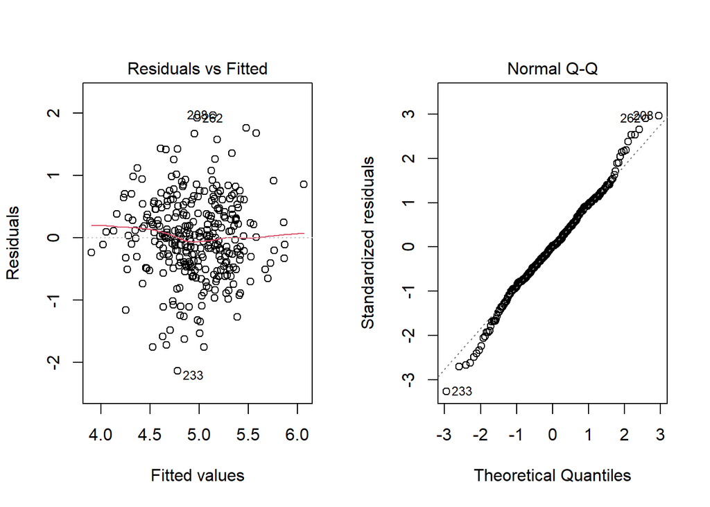

```r
par(mfrow=c(1,2))
plot(fit_7.1_final, which = 1:2)
```

Checking outliers in Y

```r
res = residuals(fit_7.1_final)
p = length(fit_7.1_final$coefficients)
h1 = influence(fit_7.1_final)$hat
d_res_std = studres(fit_7.1_final)
qt(1-0.1/(2*nrow(data)), nrow(data)-1-8)
```

```
## [1] 3.640687
```

```r
idx_Y = as.vector(which(abs(d_res_std) >= qt(1-0.1/(2*nrow(data)), nrow(data)-1-8)))
idx_Y
```

```
## integer(0)
```

- No outliers in Betaplasma

Checking for outliers in predictor variables

```r
idx_X = as.vector(which(h1 > (2*8/nrow(data))))
idx_X
```

```
##  [1]  25  28  51  94 107 121 151 189 225 261 276 292 294 306
```

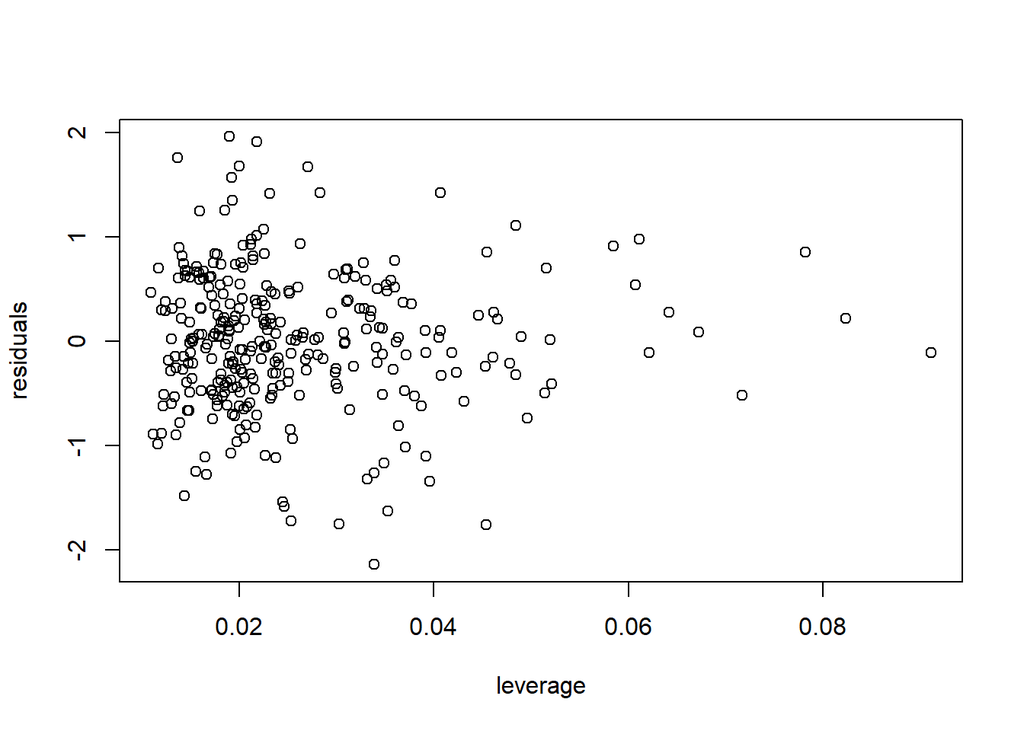

```r
plot(h1, res, xlab = "leverage", ylab = "residuals")
```

- There are 14 cases defined as outlying X observations, their indexes are shown above.

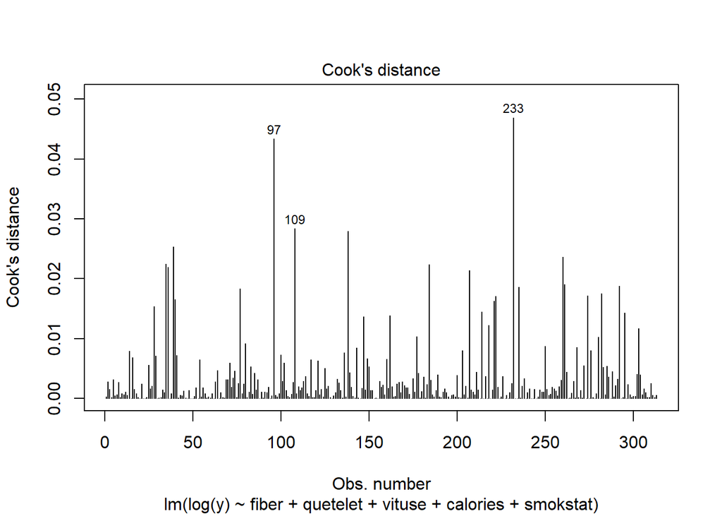

```r
plot(fit_7.1_final, which=4)
```

```r
# fit_7.1_final2 = lm(fit_7.1_final, data = data[-97,])
# f1 = fitted(fit_7.1_final)
# f2 = fitted(fit_7.1_final2)
# SUM = sum(abs((f1[-97]-f2)/f1[-97]))
# SUM = SUM + abs((f1[97] - predict(fit_fs1_final, newdata = data_s[97,]))/f1[97])
# per_average = SUM/n_s
# per_average
```